# IODS course project

Marjo Pyy-Martikainen

# Introduction to Open Data Science - Course Project

I heard about this course from Kimmo’s Facebook posting. I work as a mathematician at Kela where I have recently started learning to use Rstudio and GitHub. This seemed like a perfect course to deepen my knowledge of these tools. I also boldly hope that this course will give me new career opportunities! **Thus, feeling very excited about this course!**

My GitHub repository can be found here: https://github.com/marjopyy/IODS-project

# Exercise 2: Linear regression and model validation

## The data

The original data set was downloaded from http://www.helsinki.fi/~kvehkala/JYTmooc/JYTOPKYS3-data.txt. It contains results from a survey of students’ attitudes towards learning statistics. The data was collected among students attending the course *Introduction to Social Statistics* during fall 2014.

The analysis data contains students’ exam points, age and gender, and four variables summarising the attitude questions. Variable *Attitude* is based on 10 questions and it measures students’ global attitude towards statistics. Variables *deep*, *stra* and *surf* are averages over deep, strategic and surface questions, respectively (for more information, see <https://www.mv.helsinki.fi/home/kvehkala/JYTmooc/JYTOPKYS3-meta.txt >) After excluding students whose exam points were equal to zero, the analysis data contains information on 166 students.

```r
#read the data into R
learning2014 <- read.csv("./data/learning2014.csv")
#dimensions of the data
dim(learning2014)
```

```
## [1] 166   7
```

```r
#variable types
str(learning2014)
```

```
## 'data.frame':    166 obs. of  7 variables:
##  $ gender  : chr  "F" "M" "F" "M" ...
##  $ Age     : int  53 55 49 53 49 38 50 37 37 42 ...
##  $ Attitude: int  37 31 25 35 37 38 35 29 38 21 ...
##  $ deep    : num  3.58 2.92 3.5 3.5 3.67 ...
##  $ stra    : num  3.38 2.75 3.62 3.12 3.62 ...
##  $ surf    : num  2.58 3.17 2.25 2.25 2.83 ...
##  $ Points  : int  25 12 24 10 22 21 21 31 24 26 ...
```

## Distribution of variables and their pairwise associations

The figure below shows that the majority of students are female. Comparing female students with male students, female students’ general attitude towards statistics is more negative.  
For males, the distribution of exam points is slightly more skewed towards high points. The median for the combined variable *deep* measuring a thrive towards a thorough understanding is higher for males, whereas females have a higher median for the combined variable *stra*, which is a measure of a systematic approach to studying. The combined variable *surf* measures a lack of motivation and it has a higher median among females.

Looking at the correlations between variables, we see that exam points and the general attitude towards statistics are strongly positively correlated. The largest negative correlation can be found between variables *deep* and *surf*.

```r
# Access the libraries needed for visualization of data
library(GGally)
library(ggplot2)
```

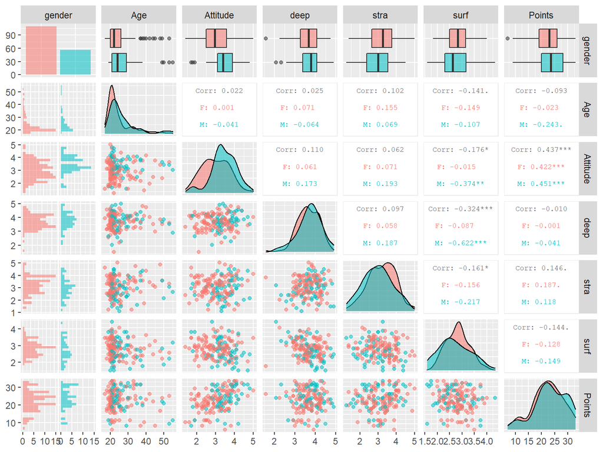

```r
# transform gender as factor for plotting
learning2014$gender <- as.factor(learning2014$gender)
# scale attitude by 10 to make it comparable with other explanatory variables
learning2014$Attitude <- learning2014$Attitude/10

p <- ggpairs(learning2014, mapping = aes(col=gender,alpha=0.3), lower = list(combo = wrap("facethist", bins = 20)), upper = list(continuous = wrap("cor", size = 2.5)))
p
```

## A linear regression model for exam points

I fit a linear regression model for exam points with three explanatory variables. The explanatory variables, *Attitude*, *stra*, and *surf*, are chosen by looking at the correlations of variable points with other variables.

The estimated parameters of the model are shown below. The intercept (11.0171) shows the estimated exam points when explanatory variables are set to zero. According to the model, a one-point increase in general attitude towards statistics increases the expected exam points by 3.3952. The estimated effect is highly significant (p-value < 0.001). This means that under the null hypothesis of no effect ($\beta=0$), it is extremely unlikely to get an estimate of $\beta$ of size 3.3952. Neither of the other explanatory variables is statistically significant.

```r
model_1 <- lm(Points ~ Attitude + stra + surf, data = learning2014)
summary(model_1)
```

```
##
## Call:
## lm(formula = Points ~ Attitude + stra + surf, data = learning2014)
##
## Residuals:
##      Min       1Q   Median       3Q      Max
## -17.1550  -3.4346   0.5156   3.6401  10.8952
##
## Coefficients:
##             Estimate Std. Error t value Pr(>|t|)
## (Intercept)  11.0171     3.6837   2.991  0.00322 **
## Attitude      3.3952     0.5741   5.913 1.93e-08 ***
## stra          0.8531     0.5416   1.575  0.11716
## surf         -0.5861     0.8014  -0.731  0.46563
## ---
## Signif. codes:  0 '***' 0.001 '**' 0.01 '*' 0.05 '.' 0.1 ' ' 1
##
## Residual standard error: 5.296 on 162 degrees of freedom
## Multiple R-squared:  0.2074, Adjusted R-squared:  0.1927
## F-statistic: 14.13 on 3 and 162 DF,  p-value: 3.156e-08
```

```r
model_2 <- lm(Points ~ Attitude + stra, data = learning2014)
summary(model_1)
```

```
##
## Call:
## lm(formula = Points ~ Attitude + stra + surf, data = learning2014)
##
## Residuals:
##      Min       1Q   Median       3Q      Max
## -17.1550  -3.4346   0.5156   3.6401  10.8952
##
## Coefficients:
##             Estimate Std. Error t value Pr(>|t|)
## (Intercept)  11.0171     3.6837   2.991  0.00322 **
## Attitude      3.3952     0.5741   5.913 1.93e-08 ***
## stra          0.8531     0.5416   1.575  0.11716
## surf         -0.5861     0.8014  -0.731  0.46563
## ---
## Signif. codes:  0 '***' 0.001 '**' 0.01 '*' 0.05 '.' 0.1 ' ' 1
##
## Residual standard error: 5.296 on 162 degrees of freedom
## Multiple R-squared:  0.2074, Adjusted R-squared:  0.1927
## F-statistic: 14.13 on 3 and 162 DF,  p-value: 3.156e-08
```

```r
model_3 <- lm(Points ~ Attitude, data = learning2014)
summary(model_1)
```

```
##
## Call:
## lm(formula = Points ~ Attitude + stra + surf, data = learning2014)
##
## Residuals:
##      Min       1Q   Median       3Q      Max
## -17.1550  -3.4346   0.5156   3.6401  10.8952
##
## Coefficients:
##             Estimate Std. Error t value Pr(>|t|)
## (Intercept)  11.0171     3.6837   2.991  0.00322 **
## Attitude      3.3952     0.5741   5.913 1.93e-08 ***
## stra          0.8531     0.5416   1.575  0.11716
## surf         -0.5861     0.8014  -0.731  0.46563
## ---
## Signif. codes:  0 '***' 0.001 '**' 0.01 '*' 0.05 '.' 0.1 ' ' 1
##
## Residual standard error: 5.296 on 162 degrees of freedom
## Multiple R-squared:  0.2074, Adjusted R-squared:  0.1927
## F-statistic: 14.13 on 3 and 162 DF,  p-value: 3.156e-08
```

## Model diagnostics

As a final step of the analysis, I draw some diagnostic plots. A linear regression model assumes that the model errors are normally distributed, with mean zero and a constant variance. The following three plots help to evaluate the validity of these assumptions.

The plot of residuals versus fitted values can be used to inspect the assumptions of zero mean and constant variance. The residuals are scattered around zero and their spread does not depend on the fitted values. With fitted values of 24 or larger, there are some large negative residuals, though.

The normal Q-Q plot shows whether the assumption of normality is met. In case the residuals are normally distributed, they should lie on a straight line in the Q-Q plot. This is approximately the case, except some deviations at the both ends of the distribution.

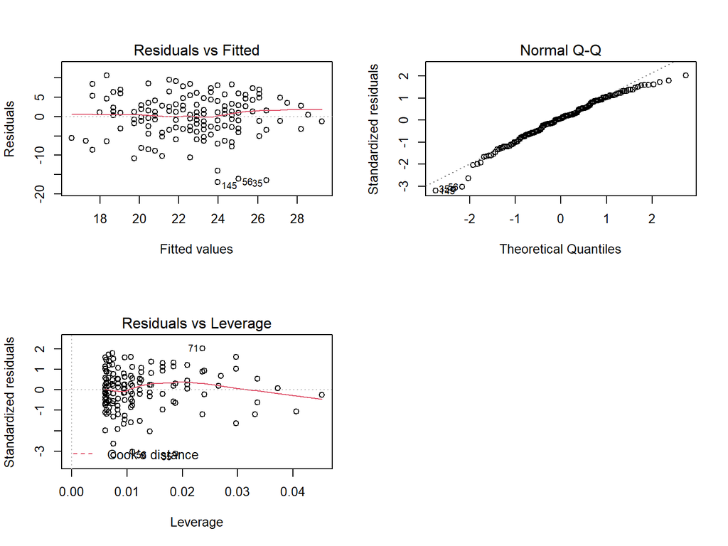

```r
par(mfrow=c(2,2))
plot(model_3,which=c(1,2,5))
```

# Exercise 3: Logistic regression

## The data

The original data set was downloaded from https://archive.ics.uci.edu/ml/datasets/Student+Performance. The data measures student achievement in secondary education of two Portuguese schools.Two datasets are provided regarding the performance in two distinct subjects: Mathematics (math) and Portuguese language (por).

The analysis data was created by combining the two datasets. because there are no common identifiers in the data sets, they were combined by using 27 background variables (sex, age, address etc.). For numerical variables absences (number of school absences), failures (number of oast class failures), G1 (first period grade), G2 (second period grade) and G3 (final grade), the mean of the two values (math and portuguese) was calculated. The combined data set has 370 observations.

```r
#read the data into R
alc <- read.csv("./data/pormath.csv")
#dimensions of the data
dim(alc)
```

```
## [1] 370  51
```

```r
#variable names
colnames(alc)
```

```
##  [1] "school"     "sex"        "age"        "address"    "famsize"
##  [6] "Pstatus"    "Medu"       "Fedu"       "Mjob"       "Fjob"
## [11] "reason"     "guardian"   "traveltime" "studytime"  "schoolsup"
## [16] "famsup"     "activities" "nursery"    "higher"     "internet"
## [21] "romantic"   "famrel"     "freetime"   "goout"      "Dalc"
## [26] "Walc"       "health"     "n"          "id.p"       "id.m"
## [31] "failures"   "paid"       "absences"   "G1"         "G2"
## [36] "G3"         "failures.p" "paid.p"     "absences.p" "G1.p"
## [41] "G2.p"       "G3.p"       "failures.m" "paid.m"     "absences.m"
## [46] "G1.m"       "G2.m"       "G3.m"       "alc_use"    "high_use"
## [51] "cid"
```

## What explains high alcohol consumption -preliminary analysis

The variable high_use is of key interest in the analysis. It is a binary variable measuring the extent of alcohol consumption (high/low). I assume the following four variables may be associated with high alcohol consumption: sex, famrel (quality of family relationships), absences (number of school absences) and G3 (average final grade from math and portuguese). I assume being a male, having poor family relationships, lots of absences from school and a low final average grade are associated with high alcohol consumption.

The bar plots below show the distributions of the variables.

```r
# Access the libraries needed
library(tidyverse)
library(ggplot2)
```

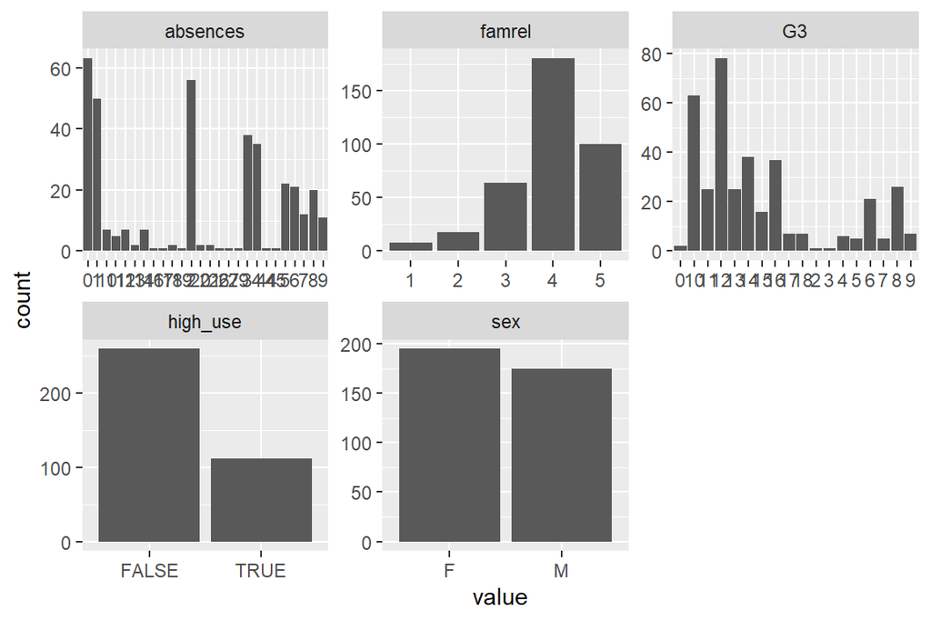

```r
# keep only variables of interest
alc <- alc %>% select(high_use,sex,famrel,absences,G3)

# and draw a bar plot of each variable
gather(alc) %>% ggplot(aes(value)) + facet_wrap("key", scales = "free") + geom_bar()
```

Looking at the distribution of alcohol consumption by sex, we see that high consumption is more common among males than females.

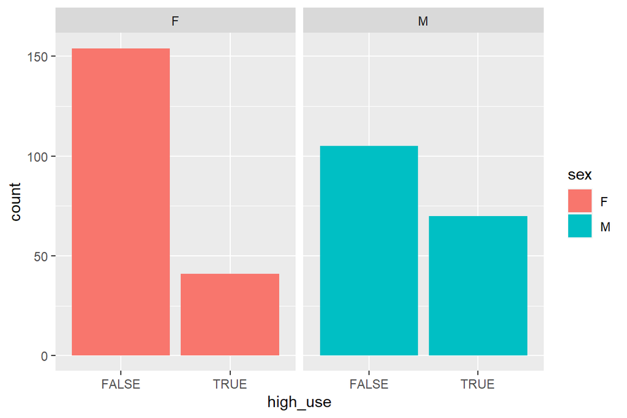

```r
# initialize a plot of high_use by sex
g <- ggplot(data = alc,aes(x = high_use, fill=sex))
# draw a bar plot of high_use by sex
g + geom_bar() + facet_wrap("sex")
```

I derive a binary variable goodrel from famrel and look at its association with high alcohol consumption. The bar plot below shows that students having good family relationships are less likely to be heavy consumers of alcohol.

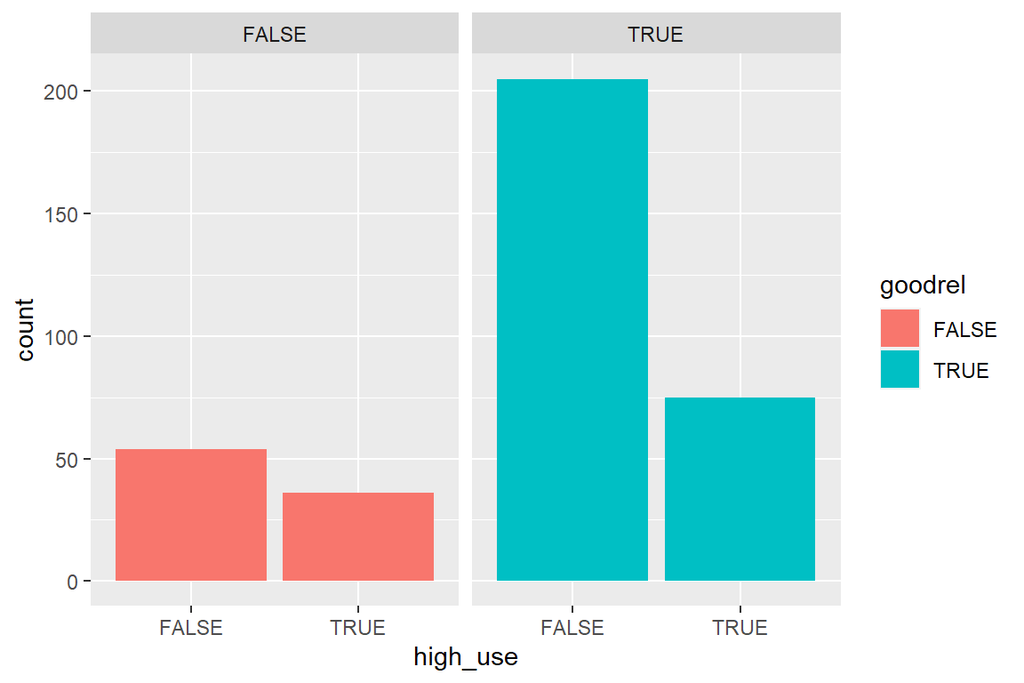

```r
# derive a binary variable goodrel from famrel
alc <- alc %>% mutate(goodrel=famrel>3)
# initialize a plot of high_use by good family relationships
g <- ggplot(data = alc,aes(x = high_use, fill=goodrel))
# draw a bar plot of high_use by goodrel
g + geom_bar() + facet_wrap("goodrel")
```

The Box plots show the associations between the continuous variables grade and absences with alcohol consumption, drawn separately for females and males. For males, high alcohol consumption is associated with lower grades, while there seems to be no association for females. Males with a high alcohol consumption have a few outlying observations at the low end of variable grade.

Similarly, for males, high alcohol consumption is associated with more absences, whereas for females, no association is present. Females tend to have a more upwards skewed distribution of absences, both among high and low consumers of alcohol.

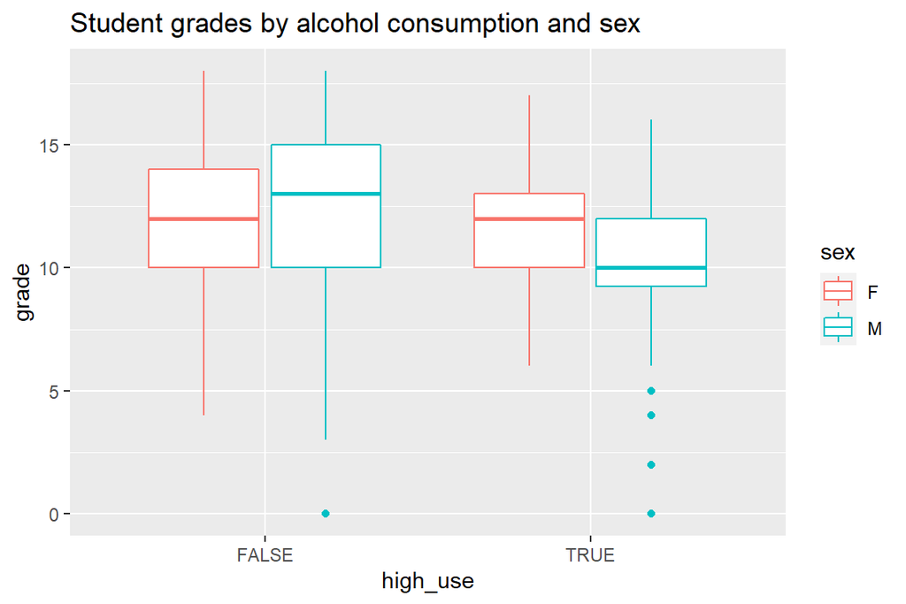

```r
# initialize a plot of high_use and G3, grouping by sex
g1 <- ggplot(alc, aes(x = high_use, y = G3,col=sex))

# define the plot as a boxplot and draw it
g1 + geom_boxplot() + ylab("grade") +
ggtitle("Student grades by alcohol consumption and sex")
```

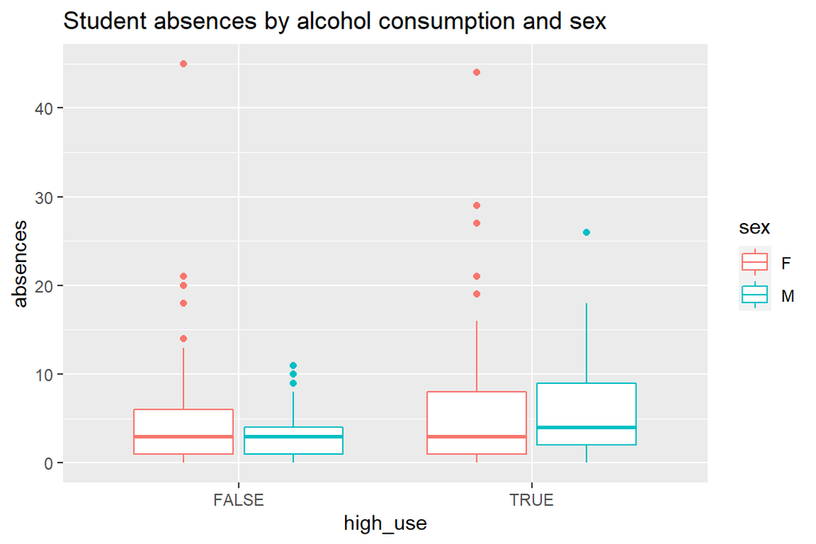

```r
# initialize a plot of high_use and absences, grouping by sex
g1 <- ggplot(alc, aes(x = high_use, y = absences,col=sex))

# define the plot as a boxplot and draw it
g1 + geom_boxplot() + ylab("absences") +
ggtitle("Student absences by alcohol consumption and sex")
```

## A logistic regression model for high alcohol consumption

I fit a logistic regression model for high_use with four explanatory variables: sex, goodrel, absences and G3.

The estimated parameters of the model are shown below. All the explanatory variables are statistically significant. For interpretation, we look at the odds ratios. Males are almost 3 times more likely to be heavy consumers of alcohol than females (OR=2.92). Good family relationships also have a strong influence: students having good family relationships are only half as likely heavy alcohol consumers compared to students with bad family relationships (OR=0.55). One additional absence from school increases the likelihood of heavy alcohol consumption by 9 percent (OR=1.09) whereas a one-point increase in average final grade decreases the likelihood by 7 percent (OR=0.93). the direction of all these associations are as hypothesized.

```r
m <- glm(high_use ~ sex + goodrel + absences + G3, data = alc, family = "binomial")

# print out a summary of the model
summary(m)
```

```
##
## Call:
## glm(formula = high_use ~ sex + goodrel + absences + G3, family = "binomial",
##     data = alc)
##
## Deviance Residuals:
##     Min       1Q   Median       3Q      Max
## -2.1136  -0.8309  -0.6003   1.0113   2.2417
##
## Coefficients:
##             Estimate Std. Error z value Pr(>|z|)
## (Intercept) -0.53650    0.50480  -1.063   0.2879
## sexM         1.07310    0.24825   4.323 1.54e-05 ***
## goodrelTRUE -0.60131    0.27070  -2.221   0.0263 *
## absences     0.08927    0.02288   3.901 9.59e-05 ***
## G3          -0.07590    0.03688  -2.058   0.0396 *
## ---
## Signif. codes:  0 '***' 0.001 '**' 0.01 '*' 0.05 '.' 0.1 ' ' 1
##
## (Dispersion parameter for binomial family taken to be 1)
##
##     Null deviance: 452.04  on 369  degrees of freedom
## Residual deviance: 406.10  on 365  degrees of freedom
## AIC: 416.1
##
## Number of Fisher Scoring iterations: 4
```

```r
# compute odds ratios (OR)
OR <- coef(m) %>% exp

# compute confidence intervals (CI)
CI <- m %>% confint %>% exp

# print out the odds ratios with their confidence intervals
cbind(OR, CI)
```

```
##                    OR     2.5 %    97.5 %
## (Intercept) 0.5847902 0.2150066 1.5664249
## sexM        2.9244297 1.8098813 4.7992289
## goodrelTRUE 0.5480912 0.3225289 0.9345182
## absences    1.0933746 1.0475287 1.1461613
## G3          0.9269129 0.8615199 0.9960499
```

## Model validation

As a final step, I conduct a simple model validation by tabulating the actual outcomes versus model predictions. The proportion of incorrectly predicted students is almost 26 percent (21.89 + 4.05). Thus, I would next search for additional explanatory variables!

```r
# predict() the probability of high_use
probabilities <- predict(m, type = "response")

# add the predicted probabilities to 'alc'
alc <- mutate(alc, probability = probabilities)

# use the probabilities to make a prediction of high_use
alc <- mutate(alc, prediction = probability>0.5)

# tabulate the target variable versus the predictions
table(high_use = alc$high_use, prediction = alc$prediction) %>% prop.table %>% addmargins()
```

```
##         prediction
## high_use      FALSE       TRUE        Sum
##    FALSE 0.65945946 0.04054054 0.70000000
##    TRUE  0.21891892 0.08108108 0.30000000
##    Sum   0.87837838 0.12162162 1.00000000
```

# Exercise 4: Clustering and classification

## The data

The data set used in this exercise contains information on census tracts in the Boston metropolitan area. The data was originally published in a paper by Harrison and Rubinfeld (1978) where it was used to model housing prices.

```r
# access the MASS package
library(MASS)
# load the data
data("Boston")
```

The data has 506 census tracts and 14 variables.

```r
# dimensions of data
dim(Boston)
```

```
## [1] 506  14
```

The variables describe median value of houses (medv), average number of rooms (rm), proportion of houses built prior to 1940 (age), neighborhood (black,lstat, crim, zn, indus, tax, ptratio, chas), accessibility (dis, rad) and air pollution (nox, part). More details can be found [here](https://stat.ethz.ch/R-manual/R-devel/library/MASS/html/Boston.html).

```r
# variables
colnames(Boston)
```

```
##  [1] "crim"    "zn"      "indus"   "chas"    "nox"     "rm"      "age"
##  [8] "dis"     "rad"     "tax"     "ptratio" "black"   "lstat"   "medv"
```

## Distributions of variables and their pairwise associations

I first look at the distributions of variables. Apart from binary variable chas (1=tract bounds Charles river), the variables are continuous.

```r
summary(Boston)
```

```
##       crim                zn             indus            chas
##  Min.   : 0.00632   Min.   :  0.00   Min.   : 0.46   Min.   :0.00000
##  1st Qu.: 0.08205   1st Qu.:  0.00   1st Qu.: 5.19   1st Qu.:0.00000
##  Median : 0.25651   Median :  0.00   Median : 9.69   Median :0.00000
##  Mean   : 3.61352   Mean   : 11.36   Mean   :11.14   Mean   :0.06917
##  3rd Qu.: 3.67708   3rd Qu.: 12.50   3rd Qu.:18.10   3rd Qu.:0.00000
##  Max.   :88.97620   Max.   :100.00   Max.   :27.74   Max.   :1.00000
##       nox               rm             age              dis
##  Min.   :0.3850   Min.   :3.561   Min.   :  2.90   Min.   : 1.130
##  1st Qu.:0.4490   1st Qu.:5.886   1st Qu.: 45.02   1st Qu.: 2.100
##  Median :0.5380   Median :6.208   Median : 77.50   Median : 3.207
##  Mean   :0.5547   Mean   :6.285   Mean   : 68.57   Mean   : 3.795
##  3rd Qu.:0.6240   3rd Qu.:6.623   3rd Qu.: 94.08   3rd Qu.: 5.188
##  Max.   :0.8710   Max.   :8.780   Max.   :100.00   Max.   :12.127
##       rad              tax           ptratio          black
##  Min.   : 1.000   Min.   :187.0   Min.   :12.60   Min.   :  0.32
##  1st Qu.: 4.000   1st Qu.:279.0   1st Qu.:17.40   1st Qu.:375.38
##  Median : 5.000   Median :330.0   Median :19.05   Median :391.44
##  Mean   : 9.549   Mean   :408.2   Mean   :18.46   Mean   :356.67
##  3rd Qu.:24.000   3rd Qu.:666.0   3rd Qu.:20.20   3rd Qu.:396.23
##  Max.   :24.000   Max.   :711.0   Max.   :22.00   Max.   :396.90
##      lstat            medv
##  Min.   : 1.73   Min.   : 5.00
##  1st Qu.: 6.95   1st Qu.:17.02
##  Median :11.36   Median :21.20
##  Mean   :12.65   Mean   :22.53
##  3rd Qu.:16.95   3rd Qu.:25.00
##  Max.   :37.97   Max.   :50.00
```

```r
# Access the libraries needed for visualization of data
library(GGally)
library(ggplot2)
```

The plot below shows that most of the variables are not normally distributed. Many of the distributions are heavily skewed (crim, zn, black, age, dis, lstat) and some two-peaked (indus, tax).

The correlation coefficients between variables are generally high, but the graphs show that in many cases the correlations are rather spurious. Looking at the graphs, a few clear associations between variables are present: a high average number of rooms in dwellings (rm) is associated with a small proportion of population with lower status (lstat) and with a high median value of homes (medv).

A high level of air pollution (nox) is associated with a high proportion of houses built prior to 1940 and with a small distance to 5 Boston employment centers. As for variable crime which is the clustering variable in the analysis following, a high crime rate is associated with low proportion of residential land zoned for large lots, high proportion of houses built prior to 1940, small distance to Boston employment centers and low value of homes.

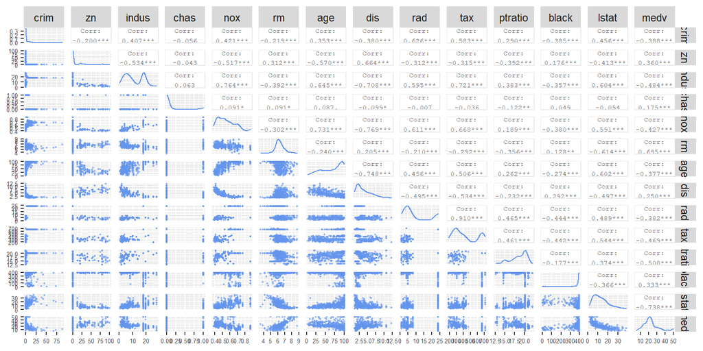

```r
library(tidyverse)
# drop variable chas
#Boston <- dplyr::select(Boston, -chas)


# plot distributions and correlations of continuous variables
p <- Boston %>%
  ggpairs(
    mapping = aes(alpha=0.5),
    lower = list(continuous = wrap("points", colour = "cornflower blue", size=0.3)),
    upper = list(continuous = wrap("cor", size = 2)),
    diag = list(continuous = wrap("densityDiag", colour = "cornflower blue"))) +
 theme(axis.text.x = element_text(size=5),
       axis.text.y = element_text(size=5))
p
```

For later use, I scale the variables so that their mean equals zero and standard deviation equals one. The table below shows that the means of scaled variables indeed equal zero. The standard deviations are not printed. The scaling does not affect the shape of the distributions of variables (scaled distributions not shown).

```r
# center and standardize variables
boston_scaled <- scale(Boston)
# change the object to data frame
boston_scaled <- as.data.frame(boston_scaled)
# summaries of the scaled variables
summary(boston_scaled,digits=2)
```

```
##       crim               zn             indus            chas
##  Min.   :-0.4194   Min.   :-0.487   Min.   :-1.56   Min.   :-0.27
##  1st Qu.:-0.4106   1st Qu.:-0.487   1st Qu.:-0.87   1st Qu.:-0.27
##  Median :-0.3903   Median :-0.487   Median :-0.21   Median :-0.27
##  Mean   : 0.0000   Mean   : 0.000   Mean   : 0.00   Mean   : 0.00
##  3rd Qu.: 0.0074   3rd Qu.: 0.049   3rd Qu.: 1.01   3rd Qu.:-0.27
##  Max.   : 9.9241   Max.   : 3.800   Max.   : 2.42   Max.   : 3.66
##       nox              rm             age             dis
##  Min.   :-1.46   Min.   :-3.88   Min.   :-2.33   Min.   :-1.27
##  1st Qu.:-0.91   1st Qu.:-0.57   1st Qu.:-0.84   1st Qu.:-0.80
##  Median :-0.14   Median :-0.11   Median : 0.32   Median :-0.28
##  Mean   : 0.00   Mean   : 0.00   Mean   : 0.00   Mean   : 0.00
##  3rd Qu.: 0.60   3rd Qu.: 0.48   3rd Qu.: 0.91   3rd Qu.: 0.66
##  Max.   : 2.73   Max.   : 3.55   Max.   : 1.12   Max.   : 3.96
##       rad             tax           ptratio          black
##  Min.   :-0.98   Min.   :-1.31   Min.   :-2.70   Min.   :-3.90
##  1st Qu.:-0.64   1st Qu.:-0.77   1st Qu.:-0.49   1st Qu.: 0.20
##  Median :-0.52   Median :-0.46   Median : 0.27   Median : 0.38
##  Mean   : 0.00   Mean   : 0.00   Mean   : 0.00   Mean   : 0.00
##  3rd Qu.: 1.66   3rd Qu.: 1.53   3rd Qu.: 0.81   3rd Qu.: 0.43
##  Max.   : 1.66   Max.   : 1.80   Max.   : 1.64   Max.   : 0.44
##      lstat            medv
##  Min.   :-1.53   Min.   :-1.91
##  1st Qu.:-0.80   1st Qu.:-0.60
##  Median :-0.18   Median :-0.14
##  Mean   : 0.00   Mean   : 0.00
##  3rd Qu.: 0.60   3rd Qu.: 0.27
##  Max.   : 3.55   Max.   : 2.99
```

Next, I create a categorical variable crime by using quartiles of variable crim as cut points. Variable crime has thus 4 classes labelled by: low, med_low, med_high and high.

```r
# create a quantile vector of crim and print it
bins <- quantile(boston_scaled$crim)
bins
```

```
##           0%          25%          50%          75%         100%
## -0.419366929 -0.410563278 -0.390280295  0.007389247  9.924109610
```

```r
# create a categorical variable 'crime'
crime <- cut(boston_scaled$crim, breaks = bins, include.lowest = TRUE,label=c("low","med_low","med_high","high"))

# look at the table of the new factor crime
table(crime)
```

```
## crime
##      low  med_low med_high     high
##      127      126      126      127
```

```r
# remove original crim from the dataset
boston_scaled <- dplyr::select(boston_scaled, -crim)

# add the new categorical value to scaled data
boston_scaled <- data.frame(boston_scaled, crime)
```

For model validation purposes, the data is randomly divided into train and test sets. The train set (80% of observations) will be used to estimate the model and the test set (20% of observations) to validate the model.

```r
# number of rows in the Boston dataset
n <- nrow(boston_scaled)

# choose randomly 80% of the rows
ind <- sample(n,  size = n * 0.8)

# create train set
train <- boston_scaled[ind,]

# create test set
test <- boston_scaled[-ind,]
```

## Linear discriminant analysis

Next I estimate a linear discriminant model with crime as the target variable. The purpose of the analysis is to identify those variables that explain whether a tract has a high or low crime rate. We have here a four-class grouping of crime rate.

A linear discriminant model assumes that explanatory variables are continuous and normally distributed given the classes defined by the target variable. Moreover, a constant variance across the explanatory variables is assumed. According to the preliminary analysis, the assumption of normality is not satisfied. I do not check whether the assumption is satisfied given the crime class but simply assume normality. The constant variance assumption is satisfied because of scaling.

The results from linear discriminant analysis are shown below. The prior probabilities show the proportions of observations belonging to the four groups in the train data. They are not exactly equal because the grouping was done with all the 506 tracts. The variable means differ across crime groups suggesting that they have an association with the crime rate.

The first linear discriminant explains 95% of the variance between the groups based on crime rate.

```r
# linear discriminant analysis
lda.fit <- lda(crime ~ ., data = train)

# print the lda.fit object
lda.fit
```

```
## Call:
## lda(crime ~ ., data = train)
##
## Prior probabilities of groups:
##       low   med_low  med_high      high
## 0.2574257 0.2450495 0.2599010 0.2376238
##
## Group means:
##                   zn      indus         chas        nox          rm        age
## low       0.99387628 -0.9060352 -0.083045403 -0.8668530  0.41743688 -0.9226667
## med_low  -0.07557637 -0.3240565  0.006051757 -0.5384388 -0.05908364 -0.3451761
## med_high -0.37943482  0.1596173  0.252617630  0.3887530  0.17178480  0.4047649
## high     -0.48724019  1.0172418 -0.067271764  1.0041367 -0.38989497  0.8030259
##                 dis        rad        tax     ptratio      black       lstat
## low       0.8608537 -0.6903373 -0.7340693 -0.43781300  0.3835344 -0.78820777
## med_low   0.3111740 -0.5317649 -0.4421577 -0.07137524  0.3160589 -0.16537346
## med_high -0.3693580 -0.3999812 -0.3138436 -0.33314828  0.1089945 -0.01675307
## high     -0.8538044  1.6368728  1.5131579  0.77931510 -0.8984004  0.89748843
##                 medv
## low       0.51248170
## med_low   0.03058953
## med_high  0.24402644
## high     -0.70079737
##
## Coefficients of linear discriminants:
##                 LD1         LD2         LD3
## zn       0.09920620  0.83669076 -1.02399045
## indus    0.06436194 -0.20573312  0.07944966
## chas    -0.08189060 -0.05795846  0.09667782
## nox      0.35242404 -0.67055966 -1.39024057
## rm      -0.07595417 -0.17453513 -0.03562356
## age      0.30775403 -0.31988996 -0.20620990
## dis     -0.02959780 -0.40386887  0.09242924
## rad      3.21615128  0.95332604 -0.40558187
## tax     -0.03129177 -0.13268363  0.97856470
## ptratio  0.09443557  0.08133882 -0.27812757
## black   -0.14973558  0.01174757  0.13898980
## lstat    0.23662776 -0.34622988  0.43301619
## medv     0.17995636 -0.42313900 -0.24310013
##
## Proportion of trace:
##    LD1    LD2    LD3
## 0.9457 0.0414 0.0129
```

The LDA biplot based on the estimated model is shown below. The observations are colored on the basis of their crime group. The arrows indicate that variable rad (index of accessibility to radial highways) is a strong predictor of linear discriminant 1, while variables nox (air pollution) and zn (prop. of residential land zoned for large lots) explain linear discriminant 2.

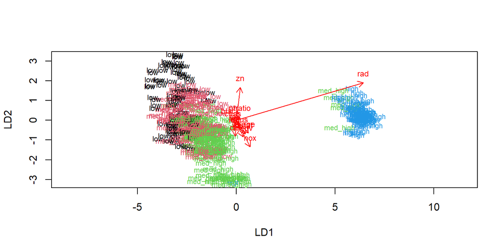

```r
# the function for lda biplot arrows
lda.arrows <- function(x, myscale = 1, arrow_heads = 0.1, color = "red", tex = 0.75, choices = c(1,2)){
  heads <- coef(x)
  arrows(x0 = 0, y0 = 0,
         x1 = myscale * heads[,choices[1]],
         y1 = myscale * heads[,choices[2]], col=color, length = arrow_heads)
  text(myscale * heads[,choices], labels = row.names(heads),
       cex = tex, col=color, pos=3)
}

# target classes as numeric
classes <- as.numeric(train$crime)

# plot the lda results
plot(lda.fit, dimen = 2, col=classes,pch=classes)

lda.arrows(lda.fit, myscale = 2)
```

## Model validation

I use the test data to validate the model, ie. to see whether the observations in the test data are correctly classified.

```r
# save the correct classes from test data
correct_classes <- test$crime

# remove the crime variable from test data
test <- dplyr::select(test, -crime)
```

```r
# predict classes with test data
lda.pred <- predict(lda.fit, newdata = test)

# cross tabulate the results
table(correct = correct_classes, predicted = lda.pred$class) %>% prop.table
```

```
##           predicted
## correct            low     med_low    med_high        high
##   low      0.107843137 0.107843137 0.009803922 0.000000000
##   med_low  0.019607843 0.215686275 0.029411765 0.000000000
##   med_high 0.000000000 0.088235294 0.107843137 0.009803922
##   high     0.000000000 0.000000000 0.000000000 0.303921569
```

## K-means clustering

As a final step, I run a K-means clustering analysis with Boston data set. K-means clustering divides observations into pre-defined number of clusters (K), by minimizing the distance of observations to cluster means (centroids). I first look at the distances between observations, using a popular distance measure, Euclidean distance.

```r
# load MASS and Boston
library(MASS)
data('Boston')

# remove variable chas
#Boston <- Boston %>% dplyr::select(-chas)

# center and standardize variables
boston_scaled <- scale(Boston)

# change the object to data frame
boston_scaled <- as.data.frame(boston_scaled)

# euclidean distance matrix
dist_eu <- dist(boston_scaled)

# look at the summary of the distances
summary(dist_eu)
```

```
##    Min. 1st Qu.  Median    Mean 3rd Qu.    Max.
##  0.1343  3.4625  4.8241  4.9111  6.1863 14.3970
```

I first choose three clusters (K=3). The plot below suggests that variables black, zn, tax and rad have a strong association with clusters. Many of the other variables seem to have a somewhat weaker effect, too.

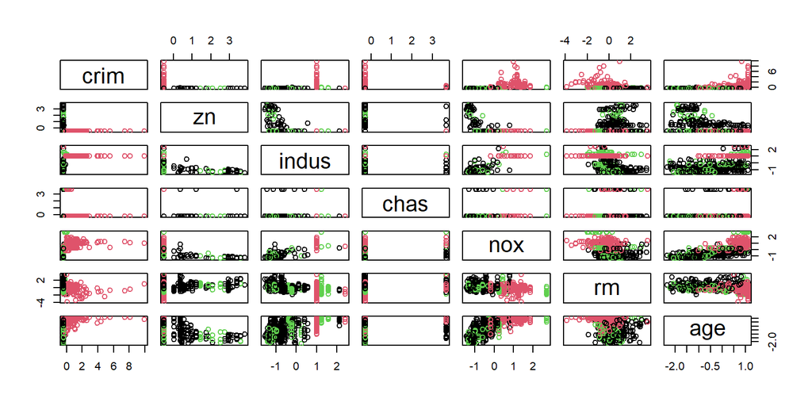

```r
# k-means clustering
km <-kmeans(Boston, centers = 3)

# plot the Boston dataset with clusters
pairs(boston_scaled[1:7], col = km$cluster)
```

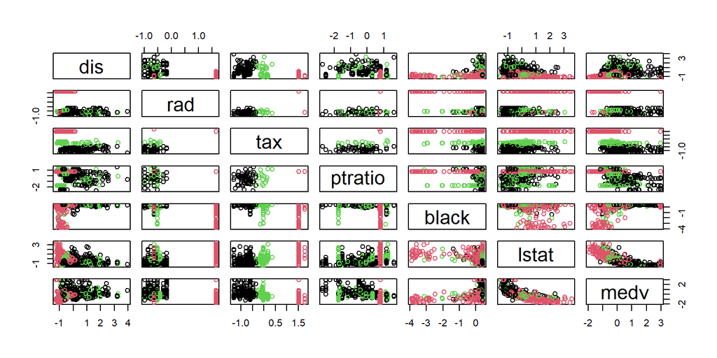

```r
pairs(boston_scaled[8:14], col = km$cluster)
```

I search for optimal number of clusters K by inspecting how the total of within cluster sum of squares (total WCSS) changes when K changes. I let K run from 1 to 10. The optimal number of clusters is the value of K where the total WCSS drops rapidly.

The plot below shows that the optimal number of clusters is 2.

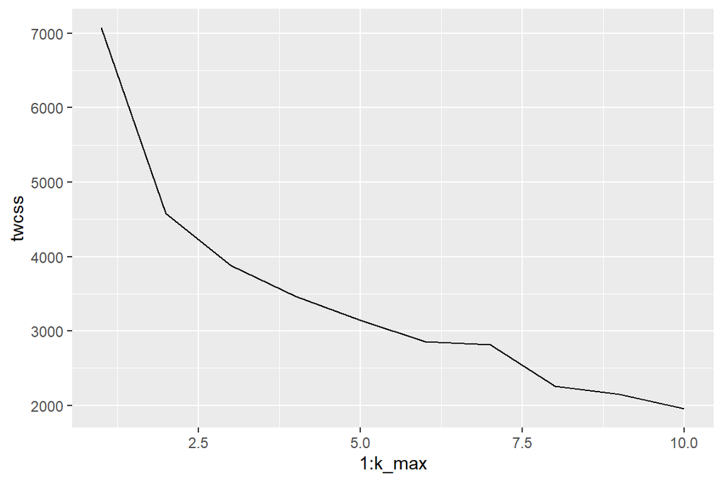

```r
set.seed(123)

# determine the number of clusters
k_max <- 10

# calculate the total within sum of squares
twcss <- sapply(1:k_max, function(k){kmeans(boston_scaled, k)$tot.withinss})

# visualize the results
qplot(x = 1:k_max, y = twcss, geom = 'line')
```

I choose K=2 and re-run the K-means clustering algoritm. The plot below gives support to dividing this data set to two clusters.

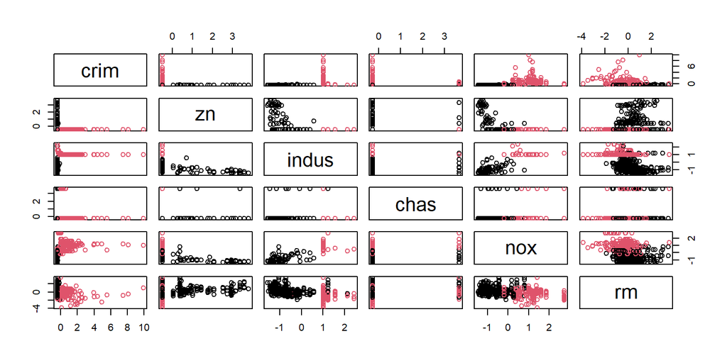

```r
# k-means clustering
km <-kmeans(boston_scaled, centers = 2)

# plot the Boston dataset with 2 clusters
pairs(boston_scaled[1:6], col = km$cluster)
```

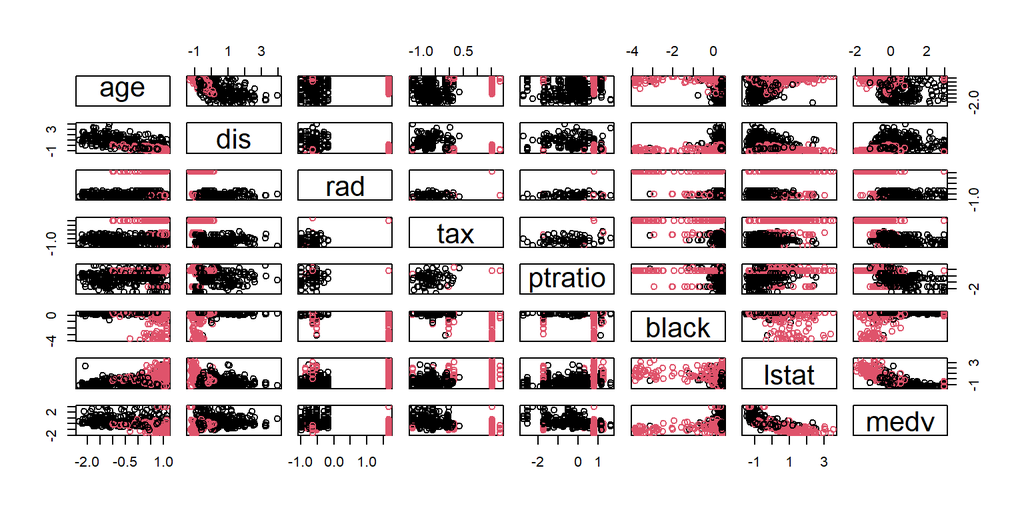

```r
pairs(boston_scaled[7:14], col = km$cluster)
```

# Exercise 5: Dimensionality reduction techniques

## The data

The data set used in this exercise is gathered by United nations. it contains several indicators for most countries of the world. The indicators are related to wealth, health, education and gender equality. The original data was retrieved from [United Nations web pages](http://hdr.undp.org/en/content/human-development-index-hdi).

```r
# Access the libraries needed for analysis
library(tidyverse)
library(GGally)
library(ggplot2)
```

```r
# load the wrangled human data
human<-get(load(file = "./data/human_f_.Rdata"))
dim(human)
```

```
## [1] 155   8
```

```r
# 155 countries and 8 variables
```

```r
# calculate summaries of variables
summary(human)
```

```
##     edu2_fm           lf_fmr          educ_exp          leb
##  Min.   :0.1717   Min.   :0.1857   Min.   : 5.40   Min.   :49.00
##  1st Qu.:0.7264   1st Qu.:0.5984   1st Qu.:11.25   1st Qu.:66.30
##  Median :0.9375   Median :0.7535   Median :13.50   Median :74.20
##  Mean   :0.8529   Mean   :0.7074   Mean   :13.18   Mean   :71.65
##  3rd Qu.:0.9968   3rd Qu.:0.8535   3rd Qu.:15.20   3rd Qu.:77.25
##  Max.   :1.4967   Max.   :1.0380   Max.   :20.20   Max.   :83.50
##       gni            mm_ratio           abr              rpar
##  Min.   :   581   Min.   :   1.0   Min.   :  0.60   Min.   : 0.00
##  1st Qu.:  4198   1st Qu.:  11.5   1st Qu.: 12.65   1st Qu.:12.40
##  Median : 12040   Median :  49.0   Median : 33.60   Median :19.30
##  Mean   : 17628   Mean   : 149.1   Mean   : 47.16   Mean   :20.91
##  3rd Qu.: 24512   3rd Qu.: 190.0   3rd Qu.: 71.95   3rd Qu.:27.95
##  Max.   :123124   Max.   :1100.0   Max.   :204.80   Max.   :57.50
```

```r
cov(human)
```

```
##                edu2_fm        lf_fmr      educ_exp           leb           gni
## edu2_fm   5.838970e-02  4.593874e-04  4.071587e-01     1.1597535  1.928166e+03
## lf_fmr    4.593874e-04  3.951293e-02  2.671701e-02    -0.2318937 -8.013518e+01
## educ_exp  4.071587e-01  2.671701e-02  8.067024e+00    18.6821956  3.288345e+04
## leb       1.159753e+00 -2.318937e-01  1.868220e+01    69.4232828  9.682497e+04
## gni       1.928166e+03 -8.013518e+01  3.288345e+04 96824.9662547  3.438745e+08
## mm_ratio -3.382434e+01  1.012323e+01 -4.425512e+02 -1512.5973775 -1.944698e+06
## abr      -5.259401e+00  9.819617e-01 -8.215424e+01  -249.7784240 -4.243095e+05
## rpar      2.182832e-01  5.714106e-01  6.724045e+00    16.2800884  1.900376e+04
##               mm_ratio           abr          rpar
## edu2_fm  -3.382434e+01 -5.259401e+00     0.2182832
## lf_fmr    1.012323e+01  9.819617e-01     0.5714106
## educ_exp -4.425512e+02 -8.215424e+01     6.7240452
## leb      -1.512597e+03 -2.497784e+02    16.2800884
## gni      -1.944698e+06 -4.243095e+05 19003.7563259
## mm_ratio  4.485483e+04  6.605745e+03  -217.6061751
## abr       6.605745e+03  1.690201e+03   -33.4746473
## rpar     -2.176062e+02 -3.347465e+01   131.9683058
```

```r
# gni has a high variance!
```

## Variable distributions and their pairwise associations

The graph below shows the distributions and pairwise associations between variables in human data. In the lower part of the plot, pairwise scatter plots of variables and a linear regression fit is shown. The correlation coefficients are shown in the upper part of the graph. Variables leb (life expectancy at birth), mm_ratio (maternal mortality ratio), abr (adolescent birth rate) and educ_exp (expected years of schooling) are strongly correlated with each other, with absolute values of correlation coefficients exceeding 0.7.

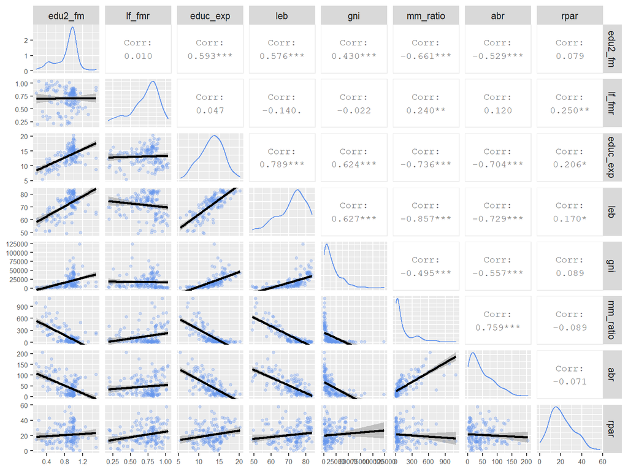

```r
# plot distributions and correlations of continuous variables
p <- human %>%
  ggpairs(
    mapping = aes(alpha=0.5),
    lower = list(continuous = wrap("smooth", colour = "cornflower blue", alpha=0.3, size=1)),
    upper = list(continuous = wrap("cor", size = 3)),
    diag = list(continuous = wrap("densityDiag", colour = "cornflower blue"))) +
 theme(axis.text.x = element_text(size=6),
       axis.text.y = element_text(size=6))
p
```

## Principal component analysis

I conduct a principal component analysis (PCA) of human data, first without any scaling of variables. PCA is a dimensionality reduction method for continuous variables that tries to capture a maximum amount of variation in a few principal components. The first principal component captures the largest share of variation, the second principal component captures the second largest share of variation etc. The number of principal components estimated is the same as the number of variables in data. However, the first few principal components capture usually most of the variation and are thus of main interest in the analysis. As PCA assumes that variables with large variance are more important than variables with small variance, it is recommendable to scale the variables before running PCA. We however first run a PCA with unscaled data.

The variation in original variables captured by principal components is shown below. The first principal component captures 99.99 % of variance so there is not much variation left for the other principal components.

```r
# perform principal component analysis (PCA)
pca_human <- prcomp(human)

# save results of PCA
res <- summary(pca_human)

# the variability of variables/features captured by principal components
pca_pr <- round(100*res$importance[2, ], digits = 2)
pca_pr
```

```
##   PC1   PC2   PC3   PC4   PC5   PC6   PC7   PC8
## 99.99  0.01  0.00  0.00  0.00  0.00  0.00  0.00
```

The biplot below shows that variable gni (gross national income per capita) has an extremely high correlation with the first principal component, PC1. Gni has by far the largest variance among variables and has therefore too much influence in the analysis. It is better to scale the variables and rerun the PCA!

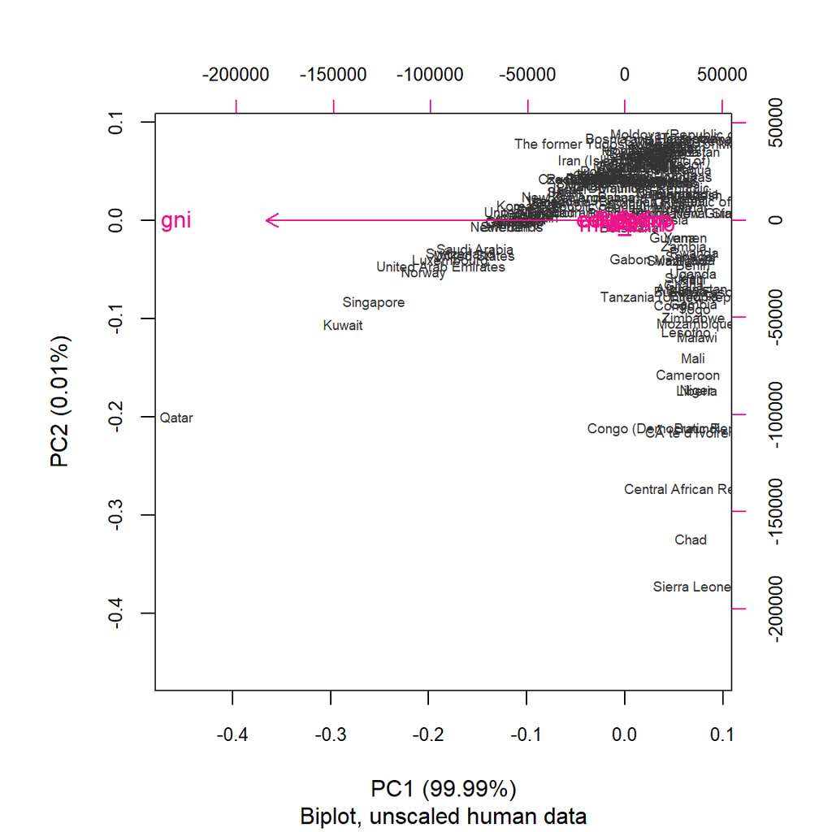

```r
# create object pc_lab to be used as axis labels
pc_lab <- paste0(names(pca_pr), " (", pca_pr, "%)")

# draw a biplot
biplot(pca_human, cex = c(0.6, 1), cex.axis=0.8, col = c("grey20", "deeppink2"), xlab = pc_lab[1], ylab = pc_lab[2],
       sub="Biplot, unscaled human data")
```

As shown below, the scaled variables have mean equal to zero and variance equal to one.

```r
# scale human data
human_scaled <- scale(human)

# let's look how scaling affects
summary(human_scaled)
```

```
##     edu2_fm            lf_fmr           educ_exp            leb
##  Min.   :-2.8189   Min.   :-2.6247   Min.   :-2.7378   Min.   :-2.7188
##  1st Qu.:-0.5233   1st Qu.:-0.5484   1st Qu.:-0.6782   1st Qu.:-0.6425
##  Median : 0.3503   Median : 0.2316   Median : 0.1140   Median : 0.3056
##  Mean   : 0.0000   Mean   : 0.0000   Mean   : 0.0000   Mean   : 0.0000
##  3rd Qu.: 0.5958   3rd Qu.: 0.7350   3rd Qu.: 0.7126   3rd Qu.: 0.6717
##  Max.   : 2.6646   Max.   : 1.6632   Max.   : 2.4730   Max.   : 1.4218
##       gni             mm_ratio            abr               rpar
##  Min.   :-0.9193   Min.   :-0.6992   Min.   :-1.1325   Min.   :-1.8203
##  1st Qu.:-0.7243   1st Qu.:-0.6496   1st Qu.:-0.8394   1st Qu.:-0.7409
##  Median :-0.3013   Median :-0.4726   Median :-0.3298   Median :-0.1403
##  Mean   : 0.0000   Mean   : 0.0000   Mean   : 0.0000   Mean   : 0.0000
##  3rd Qu.: 0.3712   3rd Qu.: 0.1932   3rd Qu.: 0.6030   3rd Qu.: 0.6127
##  Max.   : 5.6890   Max.   : 4.4899   Max.   : 3.8344   Max.   : 3.1850
```

```r
cov(human_scaled)
```

```
##               edu2_fm       lf_fmr    educ_exp        leb         gni
## edu2_fm   1.000000000  0.009564039  0.59325156  0.5760299  0.43030485
## lf_fmr    0.009564039  1.000000000  0.04732183 -0.1400125 -0.02173971
## educ_exp  0.593251562  0.047321827  1.00000000  0.7894392  0.62433940
## leb       0.576029853 -0.140012504  0.78943917  1.0000000  0.62666411
## gni       0.430304846 -0.021739705  0.62433940  0.6266641  1.00000000
## mm_ratio -0.660931770  0.240461075 -0.73570257 -0.8571684 -0.49516234
## abr      -0.529418415  0.120158862 -0.70356489 -0.7291774 -0.55656208
## rpar      0.078635285  0.250232608  0.20608156  0.1700863  0.08920818
##            mm_ratio        abr        rpar
## edu2_fm  -0.6609318 -0.5294184  0.07863528
## lf_fmr    0.2404611  0.1201589  0.25023261
## educ_exp -0.7357026 -0.7035649  0.20608156
## leb      -0.8571684 -0.7291774  0.17008631
## gni      -0.4951623 -0.5565621  0.08920818
## mm_ratio  1.0000000  0.7586615 -0.08944000
## abr       0.7586615  1.0000000 -0.07087810
## rpar     -0.0894400 -0.0708781  1.00000000
```

The results of PCA are very different after scaling. As can be seen below, the first principal component captures now only 53,6 % of the variation in the variables. Let’s see how the biplot looks now.

```r
# repeat PCA with scaled data
pca_human_scaled <- prcomp(human_scaled)

# save results of PCA
res_scaled <- summary(pca_human_scaled)


# the variability of variables/features captured by principal components
pca_pr_scaled <- round(100*res_scaled$importance[2, ], digits = 2)
pca_pr_scaled
```

```
##   PC1   PC2   PC3   PC4   PC5   PC6   PC7   PC8
## 53.61 16.24  9.57  7.58  5.48  3.60  2.63  1.30
```

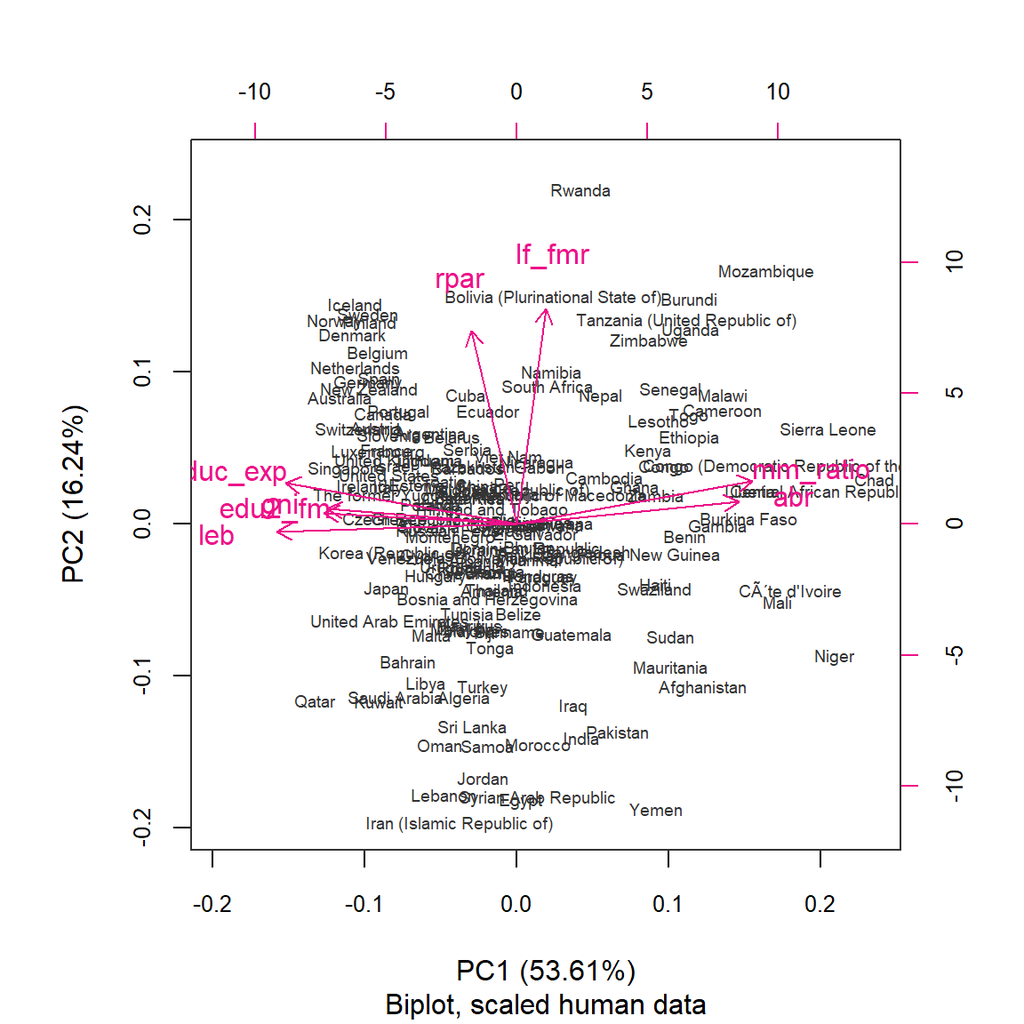

```r
# create object pc_lab to be used as axis labels
pc_lab_scaled <- paste0(names(pca_pr_scaled), " (", pca_pr_scaled, "%)")

# draw a biplot
biplot(pca_human_scaled, cex = c(0.6,1), cex.axis=0.8, col = c("grey20", "deeppink2"), xlab = pc_lab_scaled[1], ylab = pc_lab_scaled[2], sub="Biplot, scaled human data")
```

To sum up, this data seems to be well described by two dimensions. The first principal component seems to be driven by variables related to wealth, health and education, whereas the second principal component is largely driven by variables related to gender equality. It is interesting to note that as the principal components are uncorrelated, the results suggest that gender equality is not related to wealth, health and education. For example, Mozambique places itself very nicely in the dimension of gender equality, while its position in the wealth, health and education dimension is poor. The Nordic countries find themselves at a similar level of gender equality, but with a much more favourable position in the wealth, health and education dimension.

## Multiple correspondence analysis

I will next practise multiple correspondence analysis (MCA) with tea consumption data.

```r
# load the FactoMineR package
library(FactoMineR)
# load the tea data set
data("tea")
```

Let’s take a look at tea data. The data has 300 observations (an observation correponds to an answer in a survey questionnaire about tea consumption) and 36 variables. Most of the variables are categorical variables.

```r
# basic information about tea data
# number of observations and variables
dim(tea)
```

```
## [1] 300  36
```

```r
# variable types etc.
str(tea)
```

```
## 'data.frame':    300 obs. of  36 variables:
##  $ breakfast       : Factor w/ 2 levels "breakfast","Not.breakfast": 1 1 2 2 1 2 1 2 1 1 ...
##  $ tea.time        : Factor w/ 2 levels "Not.tea time",..: 1 1 2 1 1 1 2 2 2 1 ...
##  $ evening         : Factor w/ 2 levels "evening","Not.evening": 2 2 1 2 1 2 2 1 2 1 ...
##  $ lunch           : Factor w/ 2 levels "lunch","Not.lunch": 2 2 2 2 2 2 2 2 2 2 ...
##  $ dinner          : Factor w/ 2 levels "dinner","Not.dinner": 2 2 1 1 2 1 2 2 2 2 ...
##  $ always          : Factor w/ 2 levels "always","Not.always": 2 2 2 2 1 2 2 2 2 2 ...
##  $ home            : Factor w/ 2 levels "home","Not.home": 1 1 1 1 1 1 1 1 1 1 ...
##  $ work            : Factor w/ 2 levels "Not.work","work": 1 1 2 1 1 1 1 1 1 1 ...
##  $ tearoom         : Factor w/ 2 levels "Not.tearoom",..: 1 1 1 1 1 1 1 1 1 2 ...
##  $ friends         : Factor w/ 2 levels "friends","Not.friends": 2 2 1 2 2 2 1 2 2 2 ...
##  $ resto           : Factor w/ 2 levels "Not.resto","resto": 1 1 2 1 1 1 1 1 1 1 ...
##  $ pub             : Factor w/ 2 levels "Not.pub","pub": 1 1 1 1 1 1 1 1 1 1 ...
##  $ Tea             : Factor w/ 3 levels "black","Earl Grey",..: 1 1 2 2 2 2 2 1 2 1 ...
##  $ How             : Factor w/ 4 levels "alone","lemon",..: 1 3 1 1 1 1 1 3 3 1 ...
```

[output cut: 22 more lines]

```r
tea_time <- tea %>% dplyr::select(tearoom,How,where,how,sex,SPC)
```

The bar plots below show that the majority of respondents drink tea in tea bags and without milk, lemon or other addings. The majority of respondents are female,students or other non-workers and the majority do not drink their tea in a tearoom. The tea is most often bought in a chain store.

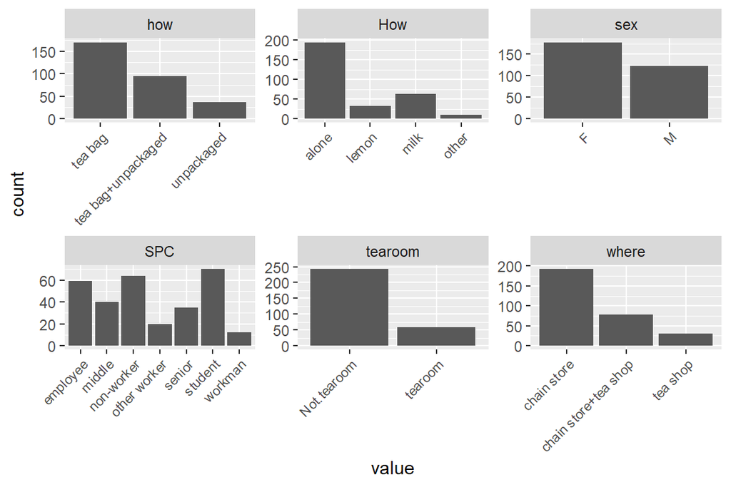

```r
gather(tea_time) %>% ggplot(aes(value)) + facet_wrap("key", scales = "free") +
geom_bar() +
theme(axis.text.x = element_text(angle = 45, hjust = 1, size = 8))
```

Next I run a multiple correspondence analysis (MCA) which is a counterpart of PCA for categorical variables.

The results of the MCA below show that the variability in the data is divided into many dimensions. The first 6 dimensions capture approximately 55% of variation in the data.

The first 10 individuals (survey responses) are also shown, with their dimension coordinates, contributions to the dimension as well as squared correlations with the dimension.

```r
# multiple correspondence analysis
mca <- MCA(tea_time, graph = FALSE)
# summary of the model
summary(mca)
```

```
##
## Call:
## MCA(X = tea_time, graph = FALSE)
##
##
## Eigenvalues
##                        Dim.1   Dim.2   Dim.3   Dim.4   Dim.5   Dim.6   Dim.7
## Variance               0.319   0.284   0.221   0.204   0.190   0.171   0.169
## % of var.             12.746  11.374   8.821   8.161   7.585   6.821   6.764
## Cumulative % of var.  12.746  24.120  32.941  41.102  48.687  55.508  62.272
##                        Dim.8   Dim.9  Dim.10  Dim.11  Dim.12  Dim.13  Dim.14
## Variance               0.164   0.157   0.141   0.125   0.114   0.101   0.081
## % of var.              6.572   6.285   5.623   5.017   4.543   4.052   3.256
## Cumulative % of var.  68.844  75.129  80.752  85.768  90.311  94.363  97.618
##                       Dim.15
## Variance               0.060
## % of var.              2.382
## Cumulative % of var. 100.000
##
## Individuals (the 10 first)
##                         Dim.1    ctr   cos2    Dim.2    ctr   cos2    Dim.3
## 1                    | -0.376  0.148  0.084 |  0.484  0.275  0.140 |  0.164
## 2                    | -0.331  0.115  0.053 |  0.141  0.023  0.010 |  0.187
## 3                    | -0.525  0.289  0.099 | -0.073  0.006  0.002 | -0.052
## 4                    | -0.662  0.458  0.384 |  0.133  0.021  0.015 |  0.051
## 5                    | -0.600  0.377  0.283 |  0.140  0.023  0.015 |  0.185
## 6                    | -0.662  0.458  0.384 |  0.133  0.021  0.015 |  0.051
## 7                    | -0.262  0.072  0.037 |  0.244  0.070  0.032 |  0.839
## 8                    | -0.331  0.115  0.053 |  0.141  0.023  0.010 |  0.187
## 9                    |  0.685  0.491  0.156 | -0.256  0.077  0.022 |  1.287
## 10                   |  1.067  1.190  0.363 | -0.439  0.226  0.061 |  0.680
##                         ctr   cos2
## 1                     0.041  0.016 |
## 2                     0.053  0.017 |
## 3                     0.004  0.001 |
## 4                     0.004  0.002 |
## 5                     0.052  0.027 |
## 6                     0.004  0.002 |
## 7                     1.063  0.379 |
## 8                     0.053  0.017 |
```

[output cut: 20 more lines]

```
## milk                   0.003  -0.967 |   1.028  16.762   0.281   9.162 |
## other                  0.094  -5.297 |   0.642   0.936   0.013   1.953 |
## chain store            0.002  -0.681 |   0.040   0.076   0.003   0.914 |
## chain store+tea shop   0.193  -7.595 |   0.106   0.220   0.004   1.085 |
## tea shop               0.497  12.195 |  -0.529   2.115   0.031  -3.049 |
## tea bag                0.000   0.145 |   0.178   1.354   0.041   3.516 |
##
## Categorical variables (eta2)
##                        Dim.1 Dim.2 Dim.3
## tearoom              | 0.350 0.093 0.019 |
## How                  | 0.161 0.102 0.310 |
## where                | 0.701 0.591 0.032 |
## how                  | 0.497 0.528 0.107 |
## sex                  | 0.001 0.200 0.408 |
## SPC                  | 0.203 0.192 0.447 |
```

Below is a biplot of the MCA results. The plot is a bit messy and not so easy to interpret. One can however see that categories indicating that tea is bought from a tea shop and is is bought unpackages are similar, which makes sense! The first dimension seems to depict some kind of a tea consumer profile. On the left side of the axis are placed students and employees who buy their tea bags from chain stores. On the right side of the axis one can find seniors who have time to enjoy their tea with lemon at tea rooms.

Overall, I found that with these variables, the MCA results are a bit difficult to interpret. I would thus continue exploring the other variables in the data in order to fine-tune my analysis of tea consumption habits!

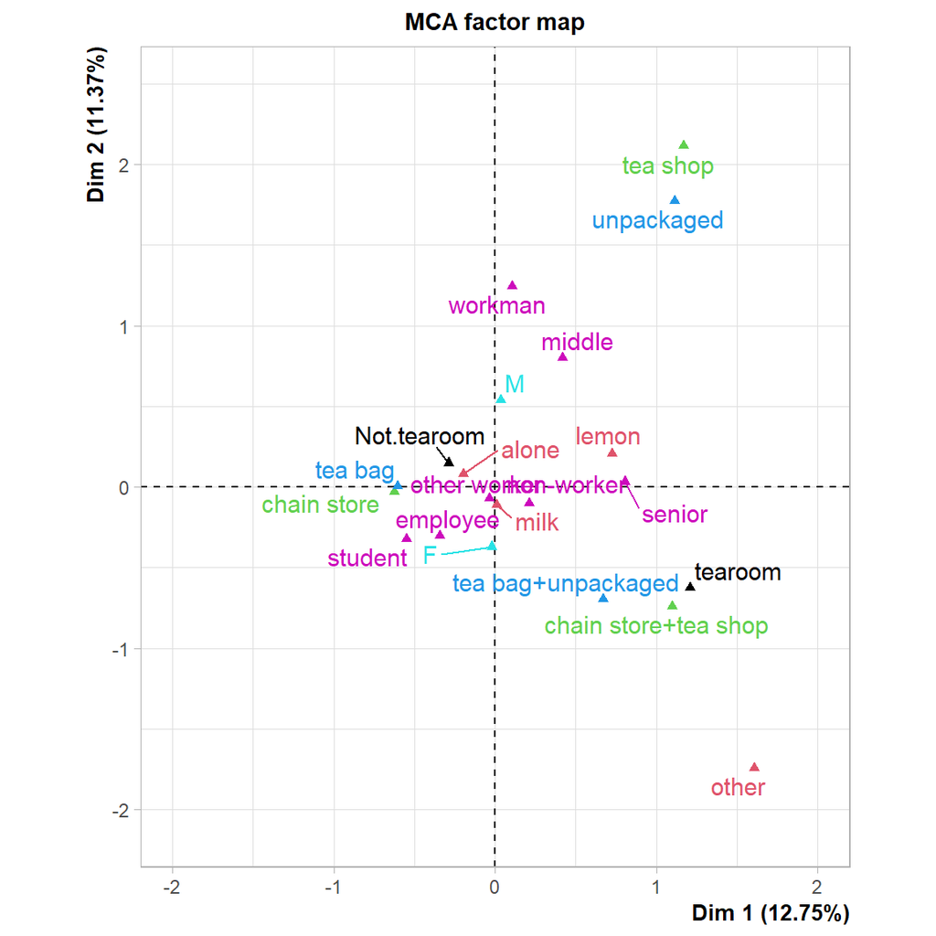

```r
# visualize MCA
plot(mca, invisible=c("ind"), habillage = "quali", xlim=c(-2,2))
```

# Exercise 6: Analysis of longitudinal data

## The data sets

In this exercise, two different data sets consisting of repeated measurements will be used.

The first data, RATS, is from a nutrition study conducted on rats. The data contains repeated measurements on 16 rats that were divided into 3 groups, each group having a different diet. The weights of rats were measured weekly over a nine week period (two measurements at week 7). I use the long form of data, where the measurements are gathered into the variable Weight. The data consists of 176 observations (16*11) and 5 variables.

```r
# load packages needed
library(tidyverse)
library(ggplot2)
```

```r
load(file = "./data/RATSL.Rdata")
dim(RATSL)
```

```
## [1] 176   5
```

```r
names(RATSL)
```

```
## [1] "ID"     "Group"  "WD"     "Weight" "Time"
```

```r
str(RATSL)
```

```
## 'data.frame':    176 obs. of  5 variables:
##  $ ID    : Factor w/ 16 levels "1","2","3","4",..: 1 2 3 4 5 6 7 8 9 10 ...
##  $ Group : Factor w/ 3 levels "1","2","3": 1 1 1 1 1 1 1 1 2 2 ...
##  $ WD    : chr  "WD1" "WD1" "WD1" "WD1" ...
##  $ Weight: int  240 225 245 260 255 260 275 245 410 405 ...
##  $ Time  : int  1 1 1 1 1 1 1 1 1 1 ...
```

The second data, BPRS, contains repeated measurements on 40 males that were randomly assigned to two treatment groups. Each male was rated using a Brief Psychiatric Rating Scale once before treatment and after treatment, 8 times at one-week intervals. The BPRS scale is used to evaluate patients suspected of having schizophrenia. I use the long form of the data, where each measurement for each male is in its own row. The data contains 360 rows (40*9) and 6 variables. An ID variable that serves as a unique identifier was added in the data earlier.

```r
load(file = "./data/BPRSL.Rdata")
dim(BPRSL)
```

```
## [1] 360   6
```

```r
names(BPRSL)
```

```
## [1] "treatment" "subject"   "ID"        "weeks"     "bprs"      "week"
```

```r
str(BPRSL)
```

```
## 'data.frame':    360 obs. of  6 variables:
##  $ treatment: Factor w/ 2 levels "1","2": 1 1 1 1 1 1 1 1 1 1 ...
##  $ subject  : Factor w/ 20 levels "1","2","3","4",..: 1 2 3 4 5 6 7 8 9 10 ...
##  $ ID       : Factor w/ 40 levels "1","2","3","4",..: 1 2 3 4 5 6 7 8 9 10 ...
##  $ weeks    : chr  "week0" "week0" "week0" "week0" ...
##  $ bprs     : int  42 58 54 55 72 48 71 30 41 57 ...
##  $ week     : int  0 0 0 0 0 0 0 0 0 0 ...
```

## Graphical displays and summary measure approach

### Weight growth profiles of individual rats

I first draw a line graph showing how each rat’s weight changes over time. The graph below shows that the rats were probably assigned to different diets on the basis of their weight (or some other feature strongly correlated with weight). Rats in group 1 have the smallest weight and rats is group 3 have the largest weight - apart from the heaviest rat who belongs to group 2. The order of the groups w.r.t. weight does not change over time.

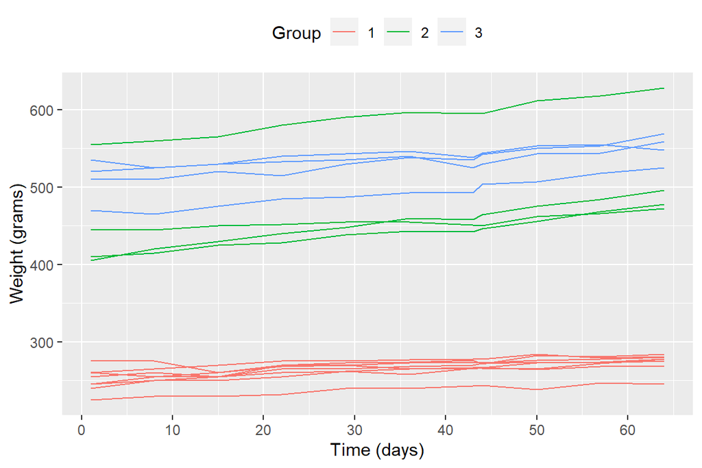

```r
# Plot the RATSL data
ggplot(RATSL, aes(x = Time, y = Weight, group = ID)) +
  geom_line(aes(color=Group)) +
# facet_grid(. ~ Group, labeller = label_both) +
# no need for faceting with this data as the groups do not overlap
  scale_x_continuous(name = "Time (days)", breaks = seq(0, 60, 10)) +
  scale_y_continuous(name = "Weight (grams)") +
  theme(legend.position = "top")
```

Let’s look how scaling affects the plot

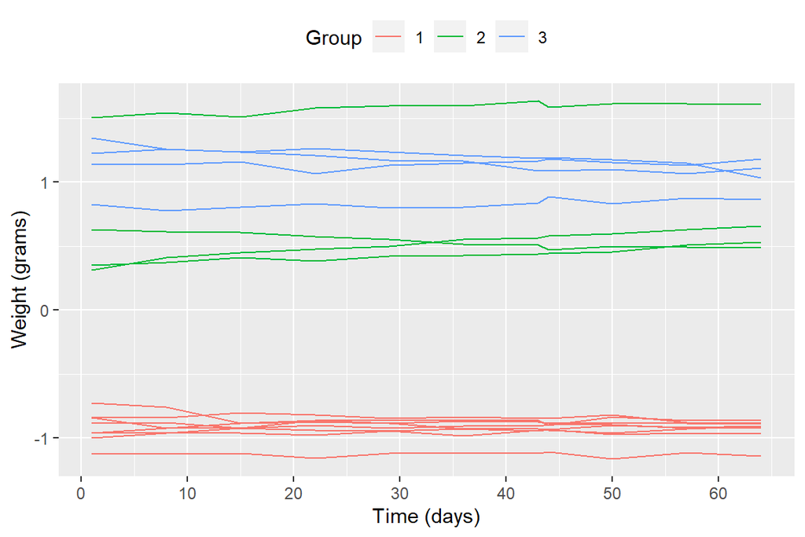

```r
RATSLS <- RATSL %>%
  group_by(Time) %>%
  mutate(stdWeight = (Weight-mean(Weight))/sd(Weight)) %>%
  ungroup()

# Plot again with the standardised Weight
ggplot(RATSLS, aes(x = Time, y = stdWeight, group = ID)) +
  geom_line(aes(color=Group)) +
  scale_x_continuous(name = "Time (days)", breaks = seq(0, 60, 10)) +
  scale_y_continuous(name = "Weight (grams)") +
  theme(legend.position = "top")
```

Scaling does not give any additional information as the tracking can be seen very clearly already from the graph based on unscaled data.

### Mean weight profiles of rats

Another way to graph longitudinal data is to plot some summary statistic for each measurement point. This may be helpful especially with large data sets containing many individuals. The RATS data only contains 16 rats but nevertheless, I plot the mean weights and their standard errors by diet group for each measurement point. The graph below confirms what could already be seen from individual weight profiles: The mean weights of rats in the three groups differ and the difference persists over time.

Looking at the slopes of the lines, it seems that the weight change is largest in group 2 and smallest in group 1. To shed some additional light to this issue, I calculate another summary measure.

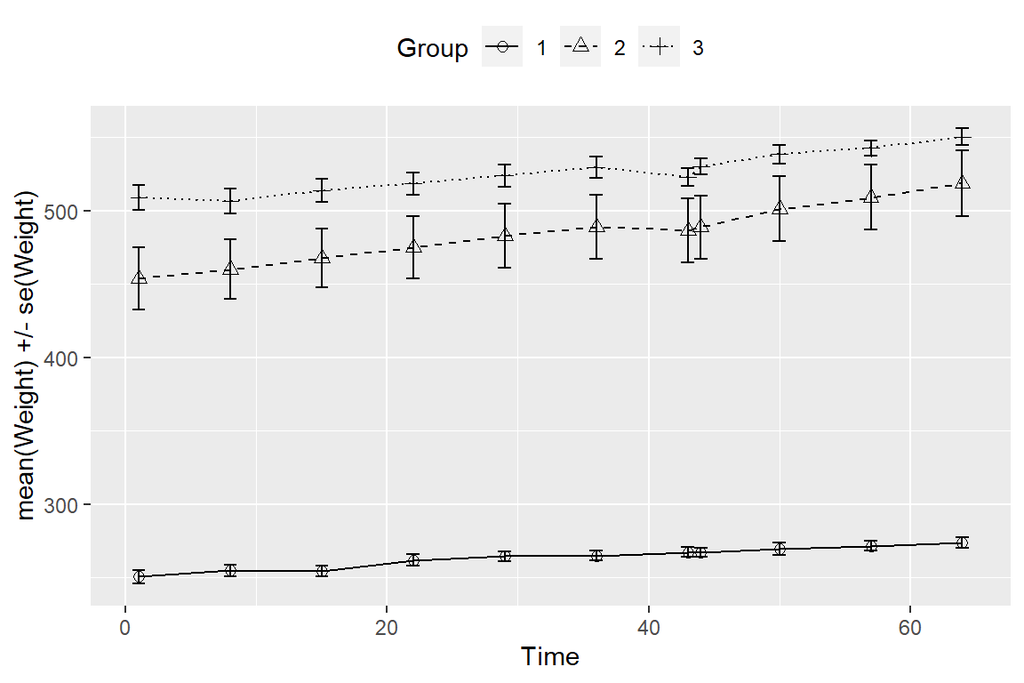

```r
# Number of weeks, baseline (week 0) included
n <- RATSL$Time %>% unique() %>% length()

# Summary data with mean and standard error of Weight by Group and Time
RATSS <- RATSL %>%
  group_by(Group, Time) %>%
  summarise( mean = mean(Weight), se = sd(Weight)/sqrt(n)) %>%
  ungroup()


# Plot the mean profiles
ggplot(RATSS, aes(x = Time, y = mean, linetype=Group, shape = Group)) +
  geom_line() +
 scale_linetype_manual(values = c(1,2,3)) +
  geom_point(size=2) +
  scale_shape_manual(values = c(1,2,3)) +
  geom_errorbar(aes(ymin=mean-se, ymax=mean+se, linetype="1"), width=1) +
  theme(legend.position = "top") +
  scale_y_continuous(name = "mean(Weight) +/- se(Weight)")
```

### Summary measure analysis

I next calculate a simple summary measure aiming to describe the differences in weight growth between the diet groups. I use as a summary measure the difference between the last and the first weight measurements.

The box plot below shows that the differences in weight change are quite clear between groups. Group 2 seems to have an outlier whose weight change is exceptionally low. I remove this observation and draw the box plot again.

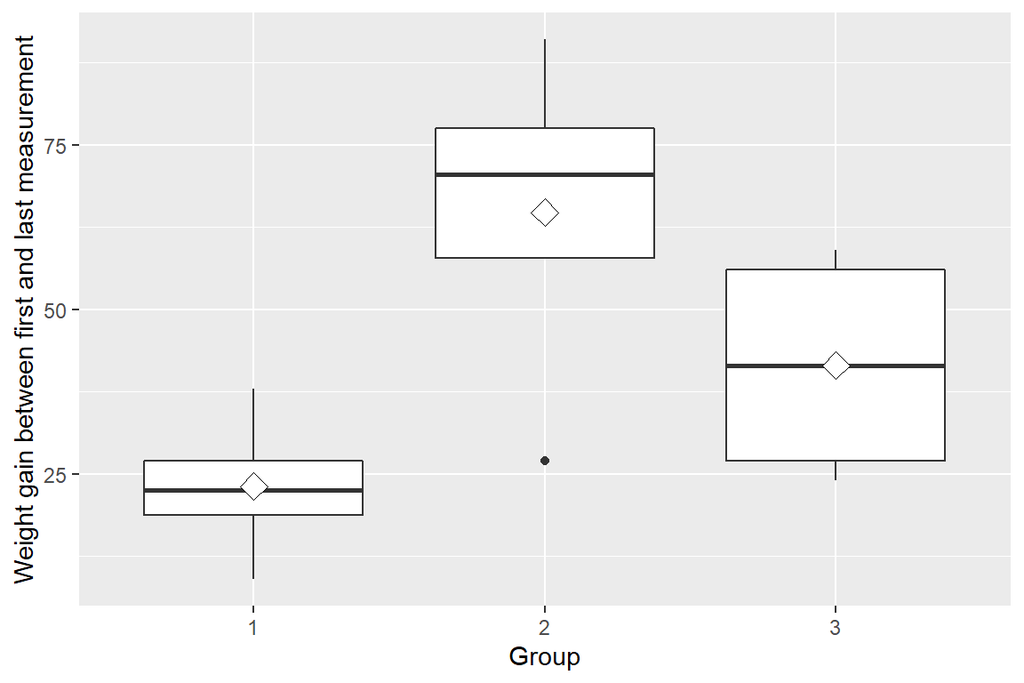

```r
# day of first measurement
first <- min(RATSL$Time)
# day of last measurement
last <- max(RATSL$Time)

# calculate for each rat the difference between last and first measurement
RATSLF <- RATSL %>% filter(Time==first) %>% rename(firstWeight=Weight) %>% dplyr::select(ID,Group,firstWeight)
RATSLL <- RATSL %>% filter(Time==last) %>% rename(lastWeight=Weight) %>%
dplyr::select(ID,Group,lastWeight)

RATSLFL <- inner_join(RATSLF,RATSLL,by=c("ID","Group")) %>%
  mutate(WeightGain=lastWeight-firstWeight)

# draw a boxplot of weight gain by Group
ggplot(RATSLFL, aes(x = Group, y = WeightGain)) +
  geom_boxplot() +
  stat_summary(fun = "mean", geom = "point", shape=23,  size=4, fill = "white") +
  scale_y_continuous(name = "Weight gain between first and last measurement")
```

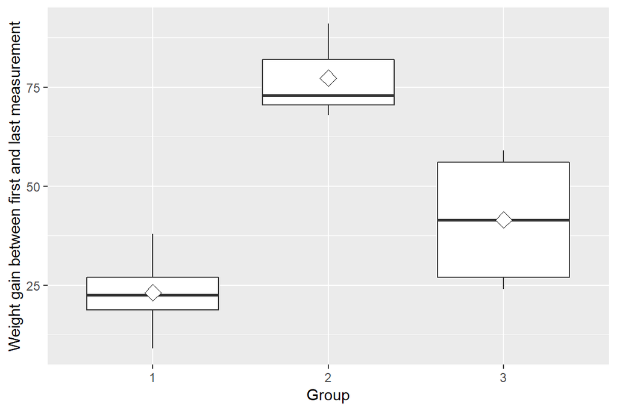

```r
# remove the outlier
RATSLFL1 <- RATSLFL %>% filter(!(Group==2 & WeightGain < 30))

# and draw the boxplot again
ggplot(RATSLFL1, aes(x = Group, y = WeightGain)) +
  geom_boxplot() +
  stat_summary(fun = "mean", geom = "point", shape=23,  size=4, fill = "white") +
  scale_y_continuous(name = "Weight gain between first and last measurement")
```

As expected, the differences between groups are larger after removing the outlier. As a last step in analyzing RATS data, I conduct an analysis of variance (ANOVA) to formally test for group differences. I include the first weight measurement in the analysis to account for its correlation with weight gain.

```r
# Fit the linear model with the mean as the response
fit <- lm(WeightGain ~ firstWeight + Group, data = RATSLFL1)

# Compute the analysis of variance table for the fitted model
anova(fit)
```

```
## Analysis of Variance Table
##
## Response: WeightGain
##             Df Sum Sq Mean Sq F value    Pr(>F)
## firstWeight  1 2521.1 2521.09  17.712 0.0014643 **
## Group        2 4234.9 2117.47  14.877 0.0007444 ***
## Residuals   11 1565.7  142.34
## ---
## Signif. codes:  0 '***' 0.001 '**' 0.01 '*' 0.05 '.' 0.1 ' ' 1
```

The ANOVA results show that the group differences in weight gain are highly significant (with risk of falsely assuming a group difference 0.0007), even after accounting for differences in rats’ weights at first measurement. Thus, according to these preliminary analyses, the diet seems to have a statistically significant effect of rats’ weight growth.

## Linear mixed effects models

I practise using linear mixed effects models with BPRS data. Before starting to specify models, I draw a graph showing individual bprs measurements in the two treatment groups. Looking at the graph, it seems that there is little difference in the individual bprs trajectories between the two groups.

It is better to study the treatment effects more formally by constructing a model that explains bprs rating.

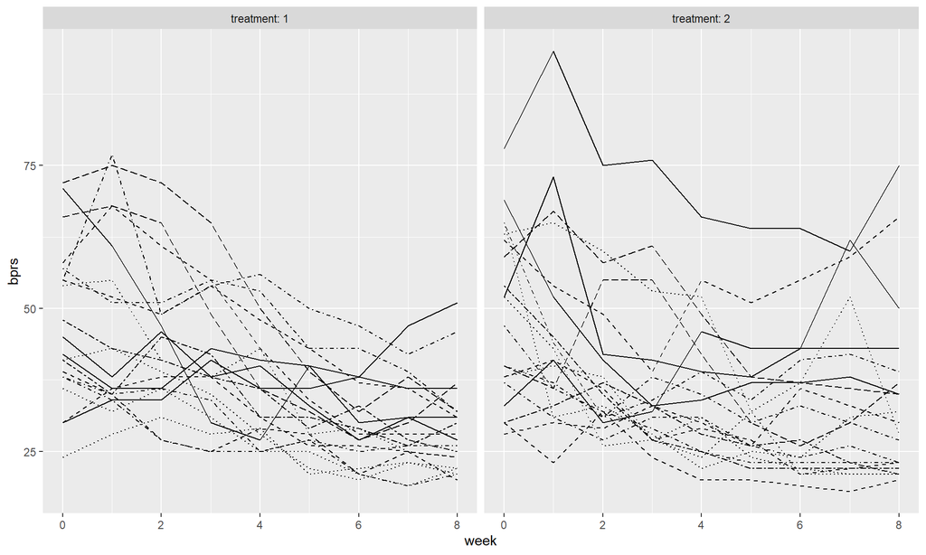

```r
ggplot(BPRSL, aes(x = week, y = bprs, linetype = subject)) +
  geom_line() +
  scale_linetype_manual(values = rep(1:10, times=4)) +
  facet_grid(. ~ treatment, labeller = label_both) +
  scale_y_continuous(name = "bprs") +
    theme(legend.position = "none")
```

### A simple linear model

Repeated measurement data consists of several measurements per individual that are highly likely to be correlated due to unobserved individual-specific features.

Even though a simple linear regression model assumes independency of observations and is therefore inappropriate for repeated measurement data, I shall start my modeling exercise with it.

As can be seen below, the treatment group has no statistically significant effect on bprs score. Each additional week decreases the bprs score by 2.1 points. The effect is highly significant. The pre-treatment bprs score is also a highly significant predictor of post-treatment score. Let’s see how the model estimates change when I allow the measurements by the same individual be correlated.

```r
# baseline = pre treatment  bprs measurement
BPRSLW0 <- BPRSL %>% filter(week==0) %>% rename(baseline=bprs) %>% dplyr::select(subject,treatment,baseline)

# post treatment measurements
BPRSLW18 <- BPRSL %>% filter(!week==0)

# combine baseline measurement with post treatment measurements
BPRSLB <- left_join(BPRSLW18,BPRSLW0, by=(c("subject","treatment")))

# a linear regression model
BPRS_reg1 <- lm(bprs ~ baseline + week + treatment, BPRSLB)

# print out a summary of the model
summary(BPRS_reg1)
```

```
##
## Call:
## lm(formula = bprs ~ baseline + week + treatment, data = BPRSLB)
##
## Residuals:
##     Min      1Q  Median      3Q     Max
## -23.491  -6.482  -1.102   4.470  36.717
##
## Coefficients:
##             Estimate Std. Error t value Pr(>|t|)
## (Intercept) 22.68834    2.32809   9.745   <2e-16 ***
## baseline     0.49127    0.04026  12.202   <2e-16 ***
## week        -2.13542    0.24456  -8.732   <2e-16 ***
## treatment2  -0.58879    1.12360  -0.524    0.601
## ---
## Signif. codes:  0 '***' 0.001 '**' 0.01 '*' 0.05 '.' 0.1 ' ' 1
##
## Residual standard error: 10.02 on 316 degrees of freedom
## Multiple R-squared:  0.4162, Adjusted R-squared:  0.4106
## F-statistic: 75.08 on 3 and 316 DF,  p-value: < 2.2e-16
```

### A random intercept linear model

The random intercept model adds an individual-specific, time-constant error term in the model. It can be interpreted as unobserved features of the individual that do not change over time. The error terms of individuals are assumed to be normally distributed with zero mean and constant variance. The individual-specific error term allows individuals to have their own intercept of the model. The slope coefficients are the same across individuals.

Compared to the simple linear regression model with independence assumption, there are no changes in the estimated effects of covariates. The standard errors of treatment effect and baseline weight are now about twice as large because of a smaller effective sample size (due to correlated observations). The standard error of time is now *smaller*, which results from a smaller model error due to taking the within-subject dependency in time into account.

The variance of individual-specific random effects is larger that the residual variance. It seems that there is important variation in the regression line intercepts between individuals.

```r
# access library lme4
library(lme4)

# a random intercept model
BPRS_reg2 <- lmer(bprs ~ baseline + week + treatment + (1 | ID), data = BPRSLB, REML = FALSE)

# Print the summary of the model
summary(BPRS_reg2)
```

```
## Linear mixed model fit by maximum likelihood  ['lmerMod']
## Formula: bprs ~ baseline + week + treatment + (1 | ID)
##    Data: BPRSLB
##
##      AIC      BIC   logLik deviance df.resid
##   2248.5   2271.1  -1118.3   2236.5      314
##
## Scaled residuals:
##      Min       1Q   Median       3Q      Max
## -2.39911 -0.58269 -0.08265  0.45618  3.04568
##
## Random effects:
##  Groups   Name        Variance Std.Dev.
##  ID       (Intercept) 51.34    7.165
##  Residual             47.88    6.920
## Number of obs: 320, groups:  ID, 40
##
## Fixed effects:
##             Estimate Std. Error t value
## (Intercept) 22.68834    4.44824   5.101
## baseline     0.49127    0.08601   5.711
## week        -2.13542    0.16883 -12.649
## treatment2  -0.58879    2.40042  -0.245
##
## Correlation of Fixed Effects:
##            (Intr) baseln week
## baseline   -0.909
## week       -0.171  0.000
## treatment2 -0.203 -0.072  0.000
```

## A random intercept and slope linear model

Next I estimate a model that allows variation not only in the intercepts but also in the slopes of different individuals.

The effects of baseline weight and treatment are now larger. The treatment effect is still not statistically significant. The effect of time (week) is the same, but the standard error is larger. According to the likelihood ratio test, the model with both random intercepts and slopes fits the data better than the model with random intercepts only .

```r
# a random intercept and random slope model
BPRS_reg3 <- lmer(bprs ~ baseline + week + treatment + (week | ID), data = BPRSLB, REML = FALSE)

# print a summary of the model
summary(BPRS_reg3)
```

```
## Linear mixed model fit by maximum likelihood  ['lmerMod']
## Formula: bprs ~ baseline + week + treatment + (week | ID)
##    Data: BPRSLB
##
##      AIC      BIC   logLik deviance df.resid
##   2183.2   2213.3  -1083.6   2167.2      312
##
## Scaled residuals:
##     Min      1Q  Median      3Q     Max
## -2.4137 -0.5005 -0.0338  0.4945  4.0665
##
## Random effects:
##  Groups   Name        Variance Std.Dev. Corr
##  ID       (Intercept) 100.098  10.005
##           week          3.075   1.754   -0.69
##  Residual              29.435   5.425
## Number of obs: 320, groups:  ID, 40
##
## Fixed effects:
##             Estimate Std. Error t value
## (Intercept) 21.67675    4.53142   4.784
## baseline     0.51870    0.08555   6.063
## week        -2.13542    0.30723  -6.950
## treatment2  -1.19835    2.38742  -0.502
##
## Correlation of Fixed Effects:
##            (Intr) baseln week
## baseline   -0.887
## week       -0.273  0.000
## treatment2 -0.198 -0.072  0.000
```

```r
# perform an ANOVA test on the two random effect models
anova(BPRS_reg3, BPRS_reg2)
```

```
## Data: BPRSLB
## Models:
## BPRS_reg2: bprs ~ baseline + week + treatment + (1 | ID)
## BPRS_reg3: bprs ~ baseline + week + treatment + (week | ID)
##           npar    AIC    BIC  logLik deviance  Chisq Df Pr(>Chisq)
## BPRS_reg2    6 2248.5 2271.1 -1118.2   2236.5
## BPRS_reg3    8 2183.2 2213.3 -1083.6   2167.2 69.317  2   8.87e-16 ***
## ---
## Signif. codes:  0 '***' 0.001 '**' 0.01 '*' 0.05 '.' 0.1 ' ' 1
```

## A random intercept and slope model with interaction between time and treatment

As a last step, I estimate a model with a random intercept, random slope and interaction between time (variable week) and treatment. The interaction lets the effect of time differ between the treatment groups.

```r
# a random intercept and random slope model with interaction btwn week and treatment
BPRS_reg4 <- lmer(bprs ~ baseline + week + treatment + week*treatment + (week | ID), data = BPRSLB, REML = FALSE)

# print a summary of the model
summary(BPRS_reg4)
```

```
## Linear mixed model fit by maximum likelihood  ['lmerMod']
## Formula: bprs ~ baseline + week + treatment + week * treatment + (week |
##     ID)
##    Data: BPRSLB
##
##      AIC      BIC   logLik deviance df.resid
##   2181.4   2215.3  -1081.7   2163.4      311
##
## Scaled residuals:
##     Min      1Q  Median      3Q     Max
## -2.4286 -0.5292 -0.0436  0.4882  4.1263
##
## Random effects:
##  Groups   Name        Variance Std.Dev. Corr
##  ID       (Intercept) 94.488   9.720
##           week         2.729   1.652    -0.66
##  Residual             29.435   5.425
## Number of obs: 320, groups:  ID, 40
##
## Fixed effects:
##                 Estimate Std. Error t value
## (Intercept)     24.04390    4.66749   5.151
## baseline         0.51871    0.08555   6.063
## week            -2.72321    0.41413  -6.576
## treatment2      -5.93385    3.35636  -1.768
## week:treatment2  1.17560    0.58568   2.007
##
## Correlation of Fixed Effects:
##             (Intr) baseln week   trtmn2
## baseline    -0.861
## week        -0.357  0.000
## treatment2  -0.315 -0.051  0.497
## wek:trtmnt2  0.253  0.000 -0.707 -0.703
```

```r
# perform an ANOVA test
anova(BPRS_reg4, BPRS_reg3)
```

```
## Data: BPRSLB
## Models:
## BPRS_reg3: bprs ~ baseline + week + treatment + (week | ID)
## BPRS_reg4: bprs ~ baseline + week + treatment + week * treatment + (week |
## BPRS_reg4:     ID)
##           npar    AIC    BIC  logLik deviance  Chisq Df Pr(>Chisq)
## BPRS_reg3    8 2183.2 2213.3 -1083.6   2167.2
## BPRS_reg4    9 2181.3 2215.3 -1081.7   2163.3 3.8388  1    0.05008 .
## ---
## Signif. codes:  0 '***' 0.001 '**' 0.01 '*' 0.05 '.' 0.1 ' ' 1
```

In the graph below, the left panel shows the observed post-treatment bprs scores and the right panel shows the fitted post-treatment bprs scores. It looks like the model depicts the observed patterns rather well.

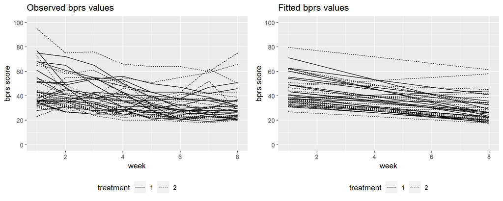

```r
# load package needed to combine two ggplots on one page
library(ggpubr)

# draw the plot of BPRSLB with the observed bprs values
p1 <- ggplot(BPRSLB, aes(x = week, y = bprs, group = ID)) +
  geom_line(aes(linetype = treatment)) +
  scale_x_continuous(name = "week") +
  scale_y_continuous(name = "bprs score", breaks = seq(0, 100, 20), limits=c(0,100)) +
  theme(legend.position = "bottom") +
  ggtitle("Observed bprs values")

# Create a vector of the fitted values
Fitted <- fitted(BPRS_reg4)

# Create a new column FittedVal
BPRSLB <- BPRSLB %>% mutate(FittedVal=Fitted)

# draw the plot of BPRSLB with the Fitted values of bprs
p2 <-  ggplot(BPRSLB, aes(x = week, y = FittedVal, group = ID)) +
  geom_line(aes(linetype = treatment)) +
  scale_x_continuous(name = "week") +
  scale_y_continuous(name = "bprs score", breaks = seq(0, 100, 20), limits=c(0,100)) +
  theme(legend.position = "bottom") +
  ggtitle("Fitted bprs values")

p12 <- ggarrange(p1,p2,ncol=2)
p12
```